# An Introduction to R

Author

Paul Smith

# Installing R and RStudio

R is the main software we need, and RStudio is an IDE to make it easier to use R. You can run R without RStudio (*e.g.* in the terminal or using the packaged R GUI), but it is highly recommended to use RStudio as it makes your life a lot easier.

**Method 1: Using the latest versions**

Ideally, you should install the latest versions of R and RStudio from the websites. This requires a servicenow request. My request code was ‘RITM0325475’ if you want to quote this when requesting R and RStudio, and my request can be seen in Figure 1.

You should also download the latest RTools software from Software Centre.

[figure not shown]

Figure 1: My ServiceNow software request

**Method 2: using software centre**

Install the latest R (currently 4.3.1), RTools (4.4), and RStudio (2022.07.2-576) from Software Centre. Install them in that order as you need R installed before using RStudio.

## Testing it all works

Once you have install R, RTools and RStudio, check it all works by starting up RStudio. It should look similar to Figure 2.

[figure not shown]

Figure 2: RStudio should look very similar to this when opened for the first time. The console (left-hand pane) is where you can type commands for R.

# Getting Started with R

In it’s simplest form, R is just a calculator. In the console, try typing `6 + 8`. The output should look like

```
[1] 14
```

Note that the `[1]` just indicates that the line begins with the first value in your result. We only have one value here, 14, so it’s not very informative.

We can *assign* values to variables using `<-`.[^1] Let’s assign our `6 + 8` to the variable `x`,

<sup>1</sup> You can also use the equals sign `=`, although I prefer only using this when assigning values to function arguments, which we’ll get to later.

```r
x <- 6 + 8
```

To check that we have assigned this correctly, just type `x` in the console,

```r
x
```

```
[1] 14
```

The main R data types are vectors, matrices and dataframes and tibbles. Tibbles are the odd one out here, as they don’t come with base R, but are instead from a package known as {tidyverse}.

## Vectors

Vectors are created using the `c()` function. For example, to create a vector of length four with elements 1, 3, 5 and 2, we write,

```r
c(1, 3, 5, 2)
```

```
[1] 1 3 5 2
```

As before, we can assign this to a variable.[^2]

<sup>2</sup> Here, I am overwriting the `x` variable we assigned earlier.

```r
x <- c(1, 3, 5, 2)
```

R is case-sensitive, so `x` and `X` are different. If you type them both into the console, you should see an error message similar to below.

```r
> x
[1] 1 3 5 2
> X
Error: object 'X' not found
```

You can extract elements of vectors using square backets. You can also write comments by starting a line with a `#`.

```r
# get the 1st element of x
x[1]
```

**1**

Note that with R, the first element is in position 1. This is different to *e.g.* python, where the indexing starts at 0.

```
[1] 1
```

```r
# get the 3rd element
x[3]
```

```
[1] 5
```

```r
# get the 2nd and 4th element
x[c(2, 4)]
```

**1**

Here, there is a vector inside the square brackets. See what happens if you type `x[2, 4]` - this will be discussed in the Matrix section below.

```
[1] 3 2
```

Vector operations are done element-wise.

```r
# square each element of x
x^2
```

```
[1]  1  9 25  4
```

```r
y <- c(1, 0, 4, 2)
# add each element of x to y
x + y
```

```
[1] 2 3 9 4
```

```r
# multiple each element of x by y
x * y
```

```
[1]  1  0 20  4
```

**Warning**

R sometimes silently recycles vectors if they are of different lengths, for example,

```r
m <- 1:10 # equivalent to c(1, 2, 3, 4, 5, 6, 7, 8, 9, 10)
n <- c(-1, 1)

m * n
```

```
 [1] -1  2 -3  4 -5  6 -7  8 -9 10
```

It will give a warning though if the length of the shorter vector does not divide into the length of the longer vector.

```r
m <- 1:10 # equivalent to c(1, 2, 3, 4, 5, 6, 7, 8, 9, 10)
n <- c(-1, 0, 1)

m * n
```

```
Warning in m * n: longer object length is not a multiple of shorter object
length
```

```
 [1]  -1   0   3  -4   0   6  -7   0   9 -10
```

The elements of vectors have to be all the same type, *e.g.* all numeric, or all characters. If you mix them, then R will change them to be the same. For example, the elements of `z` below are all changed to strings (which can be seen by the quotation marks around each element).

```r
z <- c(0, 7, "cat", as.Date("1992-09-11"))

z
```

```
[1] "0"    "7"    "cat"  "8289"
```

## Matrices

Matrices a two-dimensional objects which – like vectors – are all of the same type.

```r
X <- matrix(data = 1:12, nrow = 3)
X
```

```
     [,1] [,2] [,3] [,4]
[1,]    1    4    7   10
[2,]    2    5    8   11
[3,]    3    6    9   12
```

Here, we have coerced a vector `1:12` into a matrix with three rows. The elements have been inserted into the matrix column-wise. The object `matrix()` is actually a function[^3], which we will discuss later in Section 2.5.2. We can look at the help file by typing `?matrix` into the console. Under ‘Usage’, we can see that the `matrix()` function has the following arguments:[^4]

<sup>3</sup> similar to a macro in SAS

<sup>4</sup> Here, the equals sign is used as opposed to `<-` as we are assigning values to function arguments.

```
matrix(data = NA, nrow = 1, ncol = 1, byrow = FALSE,
       dimnames = NULL)
```

Arguments can either be called using the name, *e.g.* `data =`, or by their position. Often, the first one or two arguments are so regularly used that they are not called explicitly. For example, the following will produce the exact same matrix.

```r
X <- matrix(1:12, nrow = 3)
```

The number of columns has been calculated automatically given the length of the `data` and the `nrow` argument, so the following will produce the same matrix again:

```r
X <- matrix(1:12, nrow = 3, ncol = 4)
```

We can also set the matrix to be filled row-wise using the `byrow` argument, to create a different matrix,

```r
matrix(1:12, nrow = 3, byrow = TRUE)
```

**1**

Here we are not assigning this matrix to a variable, so it will just print out in the console and not save anywhere.

```
     [,1] [,2] [,3] [,4]
[1,]    1    2    3    4
[2,]    5    6    7    8
[3,]    9   10   11   12
```

We can extract elements using square brackets, but this time there are two dimensions, so we use a comma to separate the row index with the column index.

Recall that the matrix $X$ is,

```
     [,1] [,2] [,3] [,4]
[1,]    1    4    7   10
[2,]    2    5    8   11
[3,]    3    6    9   12
```

```r
# obtain the element in the second row and third column
X[2, 3]
```

```
[1] 8
```

```r
# obtain the third row
X[3, ]
```

**1**

Leaving the index blank means all the elements will be used. Note the output is now a one-dimensional vector.

```
[1]  3  6  9 12
```

```r
# first and third column
X[, c(1, 3)]
```

**2**

This outputs a (smaller) matrix.

```
     [,1] [,2]
[1,]    1    7
[2,]    2    8
[3,]    3    9
```

Matrix multiplication is done using `%*%`. To multiple `X` with the transpose of `X`, *i.e.*

$$\begin{pmatrix}
1 & 4 & 7 & 10 \\
2 & 5 & 8 & 11 \\
3 & 6 & 9 & 12 \\
\end{pmatrix}
\cdot
\begin{pmatrix}
1 & 2 & 3 \\
4 & 5 & 6 \\
7 & 8 & 9 \\
10 & 11 & 12 \\
\end{pmatrix}$$

we would write,

```r
X %*% t(X)
```

```
     [,1] [,2] [,3]
[1,]  166  188  210
[2,]  188  214  240
[3,]  210  240  270
```

Similarly, multiplying a matrix with a vector, `x <- c(1, 3, 5, 2)`, that is,

$$\begin{pmatrix}
1 & 4 & 7 & 10 \\
2 & 5 & 8 & 11 \\
3 & 6 & 9 & 12 \\
\end{pmatrix}
\cdot
\begin{pmatrix}
1 \\
3 \\
5 \\
2 \\
\end{pmatrix}$$

```r
X %*% x
```

```
     [,1]
[1,]   68
[2,]   79
[3,]   90
```

You can use the normal multiplication, `*`, to multiply element-wise,

```r
# multiple every element by 5
X * 5
```

```
     [,1] [,2] [,3] [,4]
[1,]    5   20   35   50
[2,]   10   25   40   55
[3,]   15   30   45   60
```

```r
X * c(1, -1, 0)
```

```
     [,1] [,2] [,3] [,4]
[1,]    1    4    7   10
[2,]   -2   -5   -8  -11
[3,]    0    0    0    0
```

## Dataframes

Dataframes are ways to store different types of data in one place - similar to how SAS datasets contain different types of data (numeric, character, logical, dates *etc.*). Each column must be the same length.

```r
df <- data.frame(
  some_numbers = c(1, 2, 3),
  strings = c("a", "b", "c"),
  logical_stuff = c(TRUE, FALSE, TRUE),
  some_dates = as.Date(c("2025-01-01", "2025-01-02", "2025-01-03"))
)

class(df)
```

```
[1] "data.frame"
```

```r
df
```

```
  some_numbers strings logical_stuff some_dates
1            1       a          TRUE 2025-01-01
2            2       b         FALSE 2025-01-02
3            3       c          TRUE 2025-01-03
```

```r
str(df)
```

**1**

The structure function `str()` is very useful for looking at data.

```
'data.frame':   3 obs. of  4 variables:
 $ some_numbers : num  1 2 3
 $ strings      : chr  "a" "b" "c"
 $ logical_stuff: logi  TRUE FALSE TRUE
 $ some_dates   : Date, format: "2025-01-01" "2025-01-02" ...
```

You can extract columns using either their index or the column names with the `$` symbol. To obtain the second column, we can do either:

```r
df[, 2]
```

```
[1] "a" "b" "c"
```

```r
df$strings
```

```
[1] "a" "b" "c"
```

## Tibbles

Tibbles are modern versions of dataframes. They require the {tidyverse} package (Wickham et al. 2019) to be installed. To do this, type `install.packages("tidyverse")` in the console. This only needs to be done once and installs the package onto the computer. Then, to use the package, we call it using the `library()` function, which needs to be run every time you start a new session.

Wickham, Hadley, Mara Averick, Jennifer Bryan, Winston Chang, Lucy D’Agostino McGowan, Romain François, Garrett Grolemund, et al. 2019. “Welcome to the tidyverse.” *Journal of Open Source Software* 4 (43): 1686. https://doi.org/10.21105/joss.01686.

```r
library(tidyverse)
```

The {tidyverse} package comes with some datasets, which we can have a look at to see an example of a tibble. A big difference between a tibble and a dataframe is in how it is visualised in the console – tibbles show the `class` of each column and truncate the number of rows and columns shown if the dataset is large.

```r
mpg
```

```
# A tibble: 234 × 11
   manufacturer model      displ  year   cyl trans drv     cty   hwy fl    class
   <chr>        <chr>      <dbl> <int> <int> <chr> <chr> <int> <int> <chr> <chr>
 1 audi         a4           1.8  1999     4 auto… f        18    29 p     comp…
 2 audi         a4           1.8  1999     4 manu… f        21    29 p     comp…
 3 audi         a4           2    2008     4 manu… f        20    31 p     comp…
 4 audi         a4           2    2008     4 auto… f        21    30 p     comp…
 5 audi         a4           2.8  1999     6 auto… f        16    26 p     comp…
 6 audi         a4           2.8  1999     6 manu… f        18    26 p     comp…
 7 audi         a4           3.1  2008     6 auto… f        18    27 p     comp…
 8 audi         a4 quattro   1.8  1999     4 manu… 4        18    26 p     comp…
 9 audi         a4 quattro   1.8  1999     4 auto… 4        16    25 p     comp…
10 audi         a4 quattro   2    2008     4 manu… 4        20    28 p     comp…
# ℹ 224 more rows
```

The `glimspe()` function is very useful when looking at the data, especially if the tibble has lots of columns.

```r
glimpse(mpg)
```

```
Rows: 234
Columns: 11
$ manufacturer <chr> "audi", "audi", "audi", "audi", "audi", "audi", "audi", "…
$ model        <chr> "a4", "a4", "a4", "a4", "a4", "a4", "a4", "a4 quattro", "…
$ displ        <dbl> 1.8, 1.8, 2.0, 2.0, 2.8, 2.8, 3.1, 1.8, 1.8, 2.0, 2.0, 2.…
$ year         <int> 1999, 1999, 2008, 2008, 1999, 1999, 2008, 1999, 1999, 200…
$ cyl          <int> 4, 4, 4, 4, 6, 6, 6, 4, 4, 4, 4, 6, 6, 6, 6, 6, 6, 8, 8, …
$ trans        <chr> "auto(l5)", "manual(m5)", "manual(m6)", "auto(av)", "auto…
$ drv          <chr> "f", "f", "f", "f", "f", "f", "f", "4", "4", "4", "4", "4…
$ cty          <int> 18, 21, 20, 21, 16, 18, 18, 18, 16, 20, 19, 15, 17, 17, 1…
$ hwy          <int> 29, 29, 31, 30, 26, 26, 27, 26, 25, 28, 27, 25, 25, 25, 2…
$ fl           <chr> "p", "p", "p", "p", "p", "p", "p", "p", "p", "p", "p", "p…
$ class        <chr> "compact", "compact", "compact", "compact", "compact", "c…
```

As is the `str`ucture function, `str()`, which I frequently use to understand a dataset, or an output from a function.

```r
str(mpg)
```

```
tibble [234 × 11] (S3: tbl_df/tbl/data.frame)
 $ manufacturer: chr [1:234] "audi" "audi" "audi" "audi" ...
 $ model       : chr [1:234] "a4" "a4" "a4" "a4" ...
 $ displ       : num [1:234] 1.8 1.8 2 2 2.8 2.8 3.1 1.8 1.8 2 ...
 $ year        : int [1:234] 1999 1999 2008 2008 1999 1999 2008 1999 1999 2008 ...
 $ cyl         : int [1:234] 4 4 4 4 6 6 6 4 4 4 ...
 $ trans       : chr [1:234] "auto(l5)" "manual(m5)" "manual(m6)" "auto(av)" ...
 $ drv         : chr [1:234] "f" "f" "f" "f" ...
 $ cty         : int [1:234] 18 21 20 21 16 18 18 18 16 20 ...
 $ hwy         : int [1:234] 29 29 31 30 26 26 27 26 25 28 ...
 $ fl          : chr [1:234] "p" "p" "p" "p" ...
 $ class       : chr [1:234] "compact" "compact" "compact" "compact" ...
```

## Functions

Functions are the R equivalent of SAS macros. R has a large number of inbuilt functions, such as `seq()`, `mean()`, `sum()`, `lm()`.[^5]

<sup>5</sup> A note on notation: if I am refering to a function in R, I will always include brackets at the end `()`.

Type `?seq` into the console. If you start typing, *e.g.* `?s`, and then press TAB, RStudio will give you a list of available help files for functions beginning with ‘s’. This autocomplete feature is very useful, and works for functions, variables, arguments and most things inbetween. Looking at the `seq()` help file, we can use the `from =` and `to =` argument to produce a sequence from 1 to 10.

```r
seq(from = 1, to = 10)
```

```
 [1]  1  2  3  4  5  6  7  8  9 10
```

But, we don’t always need to write the argument names.

```r
seq(1, 10)
```

```
 [1]  1  2  3  4  5  6  7  8  9 10
```

It also doesn’t have to have increments of 1.

```r
seq(1, 10, by = 0.5)
```

**1**

Except the first one or two arguments (function dependent) I would always use argument names.

```
 [1]  1.0  1.5  2.0  2.5  3.0  3.5  4.0  4.5  5.0  5.5  6.0  6.5  7.0  7.5  8.0
[16]  8.5  9.0  9.5 10.0
```

We can specify the length instead of the increments.

```r
seq(1, 10, length.out = 14)
```

```
 [1]  1.000000  1.692308  2.384615  3.076923  3.769231  4.461538  5.153846
 [8]  5.846154  6.538462  7.230769  7.923077  8.615385  9.307692 10.000000
```

### Dealing with `NA`’s

Missing data values in R appear as `NA`. We can create vectors (or matrices, dataframes, tibbles) with missing values.

```r
x1 <- c(1, -3, NA, 7, 17.2)
```

Lets use the `mean()` function to calculate the mean of `x1`.

```r
mean(x1)
```

```
[1] NA
```

The output is `NA`, which is sensible.[^6] But, we can tell R to ignore the `NA` values when calculating the mean. Have a look at the help file, `?mean`, and see if you can do this.[^7]

<sup>6</sup> R cannot read your mind, so doesn’t know what to do with the missing value(s).

<sup>7</sup> Hint: use the `na.rm` argument.

### Creating our own function

Suppose we want to add together two numbers and divide by 5. We can do this in the console like so:

```r
number1 <- 6
number2 <- 12

(number1 + number2) / 5
```

```
[1] 3.6
```

Sometimes creating a function makes your code more readible and reduces repetition. Lets make a function that has two inputs, adds them together and divides by 5.

```r
add_then_divide <- function(x, y) {
  add_together <- x + y
  divide_by_five <- add_together / 5
  divide_by_five
}
```

Then, we can use this function to perform the operation.

```r
add_then_divide(x = number1, y = number2)
```

```
[1] 3.6
```

## Loading data

Here we will look at loading data from excel, a csv file and from a SAS dataset.

### Reading an excel file

```r
library(readxl)
```

We are going to download an excel file and then read it into R. I have created an excel file (`.xlsx`) using the `mtcars` dataset. Download this file by clicking the button below:

Have a look at the `read_excel()` helpfile, and note that the `path` argument is the only one that doesn’t have a default value. This means we need to assign something to it. The excel spreadsheet you just downloaded should be called `example_data_set.xlsx`, and we have two options to make sure R knows where it is:

1. Move the `example_data_set.xlsx` file to the folder that R is currently working in. This can be seen by calling `getwd()`.
2. Put the path of the `example_data_set.xlsx` file into the `path` argument of `read_excel()`.

For option one, to load this excel spreadsheet into R, we would move the file into our current working folder and then do the following:

```r
example_excel1 <- read_excel(path = "example_data_set.xlsx")
```

For option two, we can use the full path of the file.

```r
example_excel2 <- read_excel(
  path = "C:/Users/smit0335/Downloads/example_data_set.xlsx"
  )
```

**1**

Your absolute path will be different to mine! We need to use forward slashes here, `/`, not backslashes.

You can also use relative paths, for example setting `path = "../data/example_data_set.xlsx"` would go up one folder, then into the “data” folder, and then read the excel spreadsheet from there.

Have a look at the data we’ve just loaded.

```r
example_excel1
```

```
# A tibble: 32 × 11
     mpg   cyl  disp    hp  drat    wt  qsec    vs    am  gear  carb
   <dbl> <dbl> <dbl> <dbl> <dbl> <dbl> <dbl> <dbl> <dbl> <dbl> <dbl>
 1  21       6  160    110  3.9   2.62  16.5     0     1     4     4
 2  21       6  160    110  3.9   2.88  17.0     0     1     4     4
 3  22.8     4  108     93  3.85  2.32  18.6     1     1     4     1
 4  21.4     6  258    110  3.08  3.22  19.4     1     0     3     1
 5  18.7     8  360    175  3.15  3.44  17.0     0     0     3     2
 6  18.1     6  225    105  2.76  3.46  20.2     1     0     3     1
 7  14.3     8  360    245  3.21  3.57  15.8     0     0     3     4
 8  24.4     4  147.    62  3.69  3.19  20       1     0     4     2
 9  22.8     4  141.    95  3.92  3.15  22.9     1     0     4     2
10  19.2     6  168.   123  3.92  3.44  18.3     1     0     4     4
# ℹ 22 more rows
```

### Reading a csv file

This is very similar to reading in an excel file, except we now use the `read_csv` function (this is from the {readr} package, which is included in the core tidyverse package[^8]). Download the below dataset:

<sup>8</sup> That is, `library(tidyverse)` also loads {readr}.

If you open this in Notepad (right click, ‘open with’, ‘Notepad’), you will see that the every element is seperated by a semicolon, `;`. Often in `.csv` files, the deliminator is either a comma, `,`, or a semicolon, `;`, so we need to make sure this is sepecified when loading in the dataset. You will also see that decimal points are given by commas, `,`.

Now, the description in the help file `?read_csv`, says

> `read_csv2()` uses `;` for the field separator and `,` for the decimal point.

This is what we have, so lets use `read_csv2()` instead!

```r
example_csv <- read_csv2("example_csv_data.csv")
```

```
ℹ Using "','" as decimal and "'.'" as grouping mark. Use `read_delim()` for more control.
```

We will discuss different types of variables later in this tutorial.

```r
example_csv
```

```
# A tibble: 32 × 11
     mpg   cyl  disp    hp  drat    wt  qsec    vs    am  gear  carb
   <dbl> <dbl> <dbl> <dbl> <dbl> <dbl> <dbl> <dbl> <dbl> <dbl> <dbl>
 1  21       6  160    110  3.9   2.62  16.5     0     1     4     4
 2  21       6  160    110  3.9   2.88  17.0     0     1     4     4
 3  22.8     4  108     93  3.85  2.32  18.6     1     1     4     1
 4  21.4     6  258    110  3.08  3.22  19.4     1     0     3     1
 5  18.7     8  360    175  3.15  3.44  17.0     0     0     3     2
 6  18.1     6  225    105  2.76  3.46  20.2     1     0     3     1
 7  14.3     8  360    245  3.21  3.57  15.8     0     0     3     4
 8  24.4     4  147.    62  3.69  3.19  20       1     0     4     2
 9  22.8     4  141.    95  3.92  3.15  22.9     1     0     4     2
10  19.2     6  168.   123  3.92  3.44  18.3     1     0     4     4
# ℹ 22 more rows
```

**Specifying column types**

We can specify the column types when loading in the dataset. Types of data are discussed later on in this tutorial. The dataset in `example_csv` is the `mtcars` dataset, so by looking at the helpfile, `?mtcars`, I think the `cyl`, `gear` and `carb` variables should be factors and the `vs`, `am` variables should be logical.

To specify this when loading the data, we would use the `col_types` argument and the compact string representation as discussed in the help file, `?read_delim`.

```r
read_csv2("example_csv_data.csv", col_types = "dfdddddllff")
```

```
# A tibble: 32 × 11
     mpg cyl    disp    hp  drat    wt  qsec vs    am    gear  carb
   <dbl> <fct> <dbl> <dbl> <dbl> <dbl> <dbl> <lgl> <lgl> <fct> <fct>
 1  21   6      160    110  3.9   2.62  16.5 FALSE TRUE  4     4
 2  21   6      160    110  3.9   2.88  17.0 FALSE TRUE  4     4
 3  22.8 4      108     93  3.85  2.32  18.6 TRUE  TRUE  4     1
 4  21.4 6      258    110  3.08  3.22  19.4 TRUE  FALSE 3     1
 5  18.7 8      360    175  3.15  3.44  17.0 FALSE FALSE 3     2
 6  18.1 6      225    105  2.76  3.46  20.2 TRUE  FALSE 3     1
 7  14.3 8      360    245  3.21  3.57  15.8 FALSE FALSE 3     4
 8  24.4 4      147.    62  3.69  3.19  20   TRUE  FALSE 4     2
 9  22.8 4      141.    95  3.92  3.15  22.9 TRUE  FALSE 4     2
10  19.2 6      168.   123  3.92  3.44  18.3 TRUE  FALSE 4     4
# ℹ 22 more rows
```

### Reading a SAS data file

To read in a SAS data file – a file that ends in `.sas7bdat` – we need to use the {haven} package (Wickham, Miller, and Smith 2023). This is part of the tidyverse but needs to be loaded separately.

Wickham, Hadley, Evan Miller, and Danny Smith. 2023. *Haven: Import and Export ’SPSS’, ’Stata’ and ’SAS’ Files*. https://CRAN.R-project.org/package=haven.

```r
library(haven)
```

The [package overview](https://haven.tidyverse.org/index.html) says:

> `read_sas()` reads `.sas7bdat` + `.sas7bcat` files and `read_xpt()` reads SAS transport files (versions 5 and 8). `write_xpt()` writes SAS transport files (versions 5 and 8).

Here, we’re just going to load the `iris` dataset that is included as an example in the {haven} package. We use the `system.file()` to obtain the path where the dataset is saved.

```r
path <- system.file("examples", "iris.sas7bdat", package = "haven")
my_sas_dataset <- read_sas(path)
my_sas_dataset
```

**1**

You can see what this path is by typing `path` in the console.

**2**

Notice that the output has automatically set some columns to the `dbl` and the `Species` column to be `chr` (*i.e.* a string).

```
# A tibble: 150 × 5
   Sepal_Length Sepal_Width Petal_Length Petal_Width Species
          <dbl>       <dbl>        <dbl>       <dbl> <chr>
 1          5.1         3.5          1.4         0.2 setosa
 2          4.9         3            1.4         0.2 setosa
 3          4.7         3.2          1.3         0.2 setosa
 4          4.6         3.1          1.5         0.2 setosa
 5          5           3.6          1.4         0.2 setosa
 6          5.4         3.9          1.7         0.4 setosa
 7          4.6         3.4          1.4         0.3 setosa
 8          5           3.4          1.5         0.2 setosa
 9          4.4         2.9          1.4         0.2 setosa
10          4.9         3.1          1.5         0.1 setosa
# ℹ 140 more rows
```

We can also create SAS transport files from R using the `write_xpt()` function. Don’t use `write_sas()`, as it is depreciated, as described in the help file, `?write_sas()`.

# Creating a plot

In this chapter, we are going to produce a plot that looks like Figure 3. This uses the {ggplot2} package, which is included in the {tidyverse} package we loaded earlier. We can also produce plots using base R functions[^9], but I feel like ggplot is more user friendly and can create nicer looking plots with less effort.

<sup>9</sup> e.g. try typing `plot(density(rnorm(100)))` to create a kernel density plot of 100 standard normal realisations.

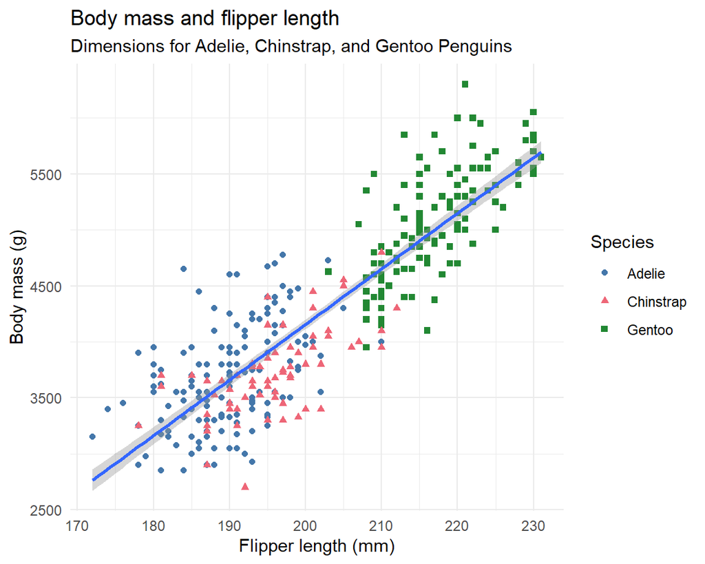

Figure 3: A figure showing the body mass and flipper length of three types of penguins, with a linear line of best fit.

This chapter is adapted from Wickham, Çetinkaya-Rundel, and Grolemund (2023, Data Visualisation chapter), which can be read online for free [here](https://r4ds.hadley.nz/data-visualize).

Wickham, Hadley, Mine Çetinkaya-Rundel, and Garrett Grolemund. 2023. *R for Data Science*. " O’Reilly Media, Inc.".

## The data

We will use data on penguins, obtained from the [{palmerpenguins}](https://allisonhorst.github.io/palmerpenguins/) package (Horst, Hill, and Gorman 2020). This is a popular alternative to the [`iris` dataset](https://en.wikipedia.org/wiki/Iris_flower_data_set), which was created by Ronald Fisher.[^10]

Horst, Allison Marie, Alison Presmanes Hill, and Kristen B Gorman. 2020. *Palmerpenguins: Palmer Archipelago (Antarctica) Penguin Data*. https://doi.org/10.5281/zenodo.3960218.

<sup>10</sup> who was a eugenicist and took money from the tobacco industry to muddy the waters.

<sup>11</sup> Hint, use `install.packages()`

First, you will need to install the {palmerpenguins} package.[^11] Then, load the package into R, using `library()`. Then, the dataset can be viewed by:

```r
penguins
```

```
# A tibble: 344 × 8
   species island    bill_length_mm bill_depth_mm flipper_length_mm body_mass_g
   <fct>   <fct>              <dbl>         <dbl>             <int>       <int>
 1 Adelie  Torgersen           39.1          18.7               181        3750
 2 Adelie  Torgersen           39.5          17.4               186        3800
 3 Adelie  Torgersen           40.3          18                 195        3250
 4 Adelie  Torgersen           NA            NA                  NA          NA
 5 Adelie  Torgersen           36.7          19.3               193        3450
 6 Adelie  Torgersen           39.3          20.6               190        3650
 7 Adelie  Torgersen           38.9          17.8               181        3625
 8 Adelie  Torgersen           39.2          19.6               195        4675
 9 Adelie  Torgersen           34.1          18.1               193        3475
10 Adelie  Torgersen           42            20.2               190        4250
# ℹ 334 more rows
# ℹ 2 more variables: sex <fct>, year <int>
```

**Factors**

The `species` and `island` columns are *factors*, which are similar to SAS formats. We can see the values of the factors using `levels()`.

```r
levels(penguins$species)
```

```
[1] "Adelie"    "Chinstrap" "Gentoo"
```

This data frame contains 8 columns. Notice from the last line of the output above that there are two variables that are not shown, `sex <fct>, year <int>`. For an alternative view that allows you to see all variables and the first few observations of each variable, use `glimpse()`.

```r
glimpse(penguins)
```

```
Rows: 344
Columns: 8
$ species           <fct> Adelie, Adelie, Adelie, Adelie, Adelie, Adelie, Adel…
$ island            <fct> Torgersen, Torgersen, Torgersen, Torgersen, Torgerse…
$ bill_length_mm    <dbl> 39.1, 39.5, 40.3, NA, 36.7, 39.3, 38.9, 39.2, 34.1, …
$ bill_depth_mm     <dbl> 18.7, 17.4, 18.0, NA, 19.3, 20.6, 17.8, 19.6, 18.1, …
$ flipper_length_mm <int> 181, 186, 195, NA, 193, 190, 181, 195, 193, 190, 186…
$ body_mass_g       <int> 3750, 3800, 3250, NA, 3450, 3650, 3625, 4675, 3475, …
$ sex               <fct> male, female, female, NA, female, male, female, male…
$ year              <int> 2007, 2007, 2007, 2007, 2007, 2007, 2007, 2007, 2007…
```

Or, if you’re in RStudio, run `View(penguins)` to open an interactive data viewer similar to how you would view a dataset in SAS.[^12]

<sup>12</sup> You can also double-click on the data in the top-right window in RStudio, under the ‘Environment’ tab.

Among the variables in `penguins` are:

1. `species`: a penguin’s species (Adelie, Chinstrap, or Gentoo).
2. `flipper_length_mm`: length of a penguin’s flipper, in millimeters.
3. `body_mass_g`: body mass of a penguin, in grams.

To learn more about `penguins`, open its help page by running `?penguins`.

## Creating a ggplot

Let’s recreate the plot in Figure 3 step-by-step.

With ggplot2, you begin a plot with the function `ggplot()`, defining a plot object that you then add **layers** to. The first argument of `ggplot()` is the dataset to use in the graph and so `ggplot(data = penguins)` creates an empty graph that is primed to display the `penguins` data, but since we haven’t told it how to visualize it yet, for now it’s empty. This is not a very exciting plot, but you can think of it like an empty canvas you’ll paint the remaining layers of your plot onto.

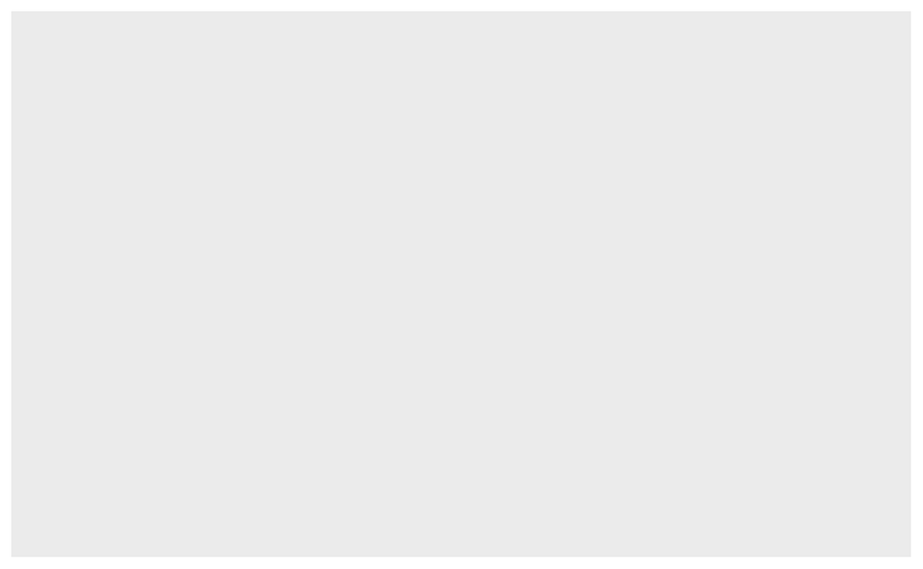

```r
ggplot(data = penguins)
```

Next, we need to tell `ggplot()` how the information from our data will be visually represented. The `mapping` argument of the `ggplot()` function defines how variables in your dataset are mapped to visual properties (**aesthetics**) of your plot. The `mapping` argument is always defined in the `aes()` function, and the `x` and `y` arguments of `aes()` specify which variables to map to the x and y axes. For now, we will only map flipper length to the `x` aesthetic and body mass to the `y` aesthetic. ggplot2 looks for the mapped variables in the `data` argument, in this case, `penguins`.

The following plot shows the result of adding these mappings.

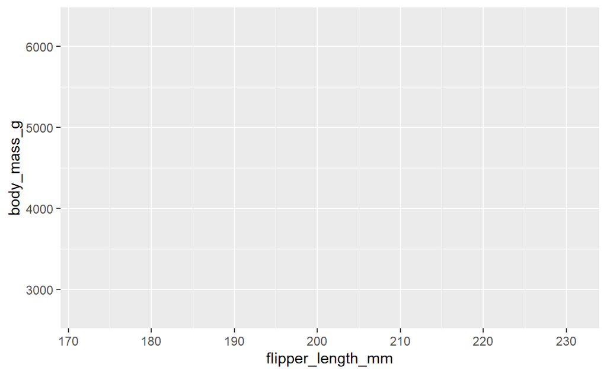

```r
ggplot(
  data = penguins,
  mapping = aes(x = flipper_length_mm, y = body_mass_g)
)
```

Our empty canvas now has more structure – it’s clear where flipper lengths will be displayed (on the x-axis) and where body masses will be displayed (on the y-axis). But the penguins themselves are not yet on the plot. This is because we have not yet articulated, in our code, how to represent the observations from our data frame on our plot.

To do so, we need to define a **geom**: the geometrical object that a plot uses to represent data. These geometric objects are made available in ggplot2 with functions that start with `geom_`. People often describe plots by the type of geom that the plot uses. For example, bar charts use bar geoms (`geom_bar()`), line charts use line geoms (`geom_line()`), boxplots use boxplot geoms (`geom_boxplot()`), scatterplots use point geoms (`geom_point()`), and so on.

The function `geom_point()` adds a layer of points to your plot, which creates a scatterplot. ggplot2 comes with many geom functions that each adds a different type of layer to a plot.

```
Warning: Removed 2 rows containing missing values or values outside the scale range
(`geom_point()`).
```

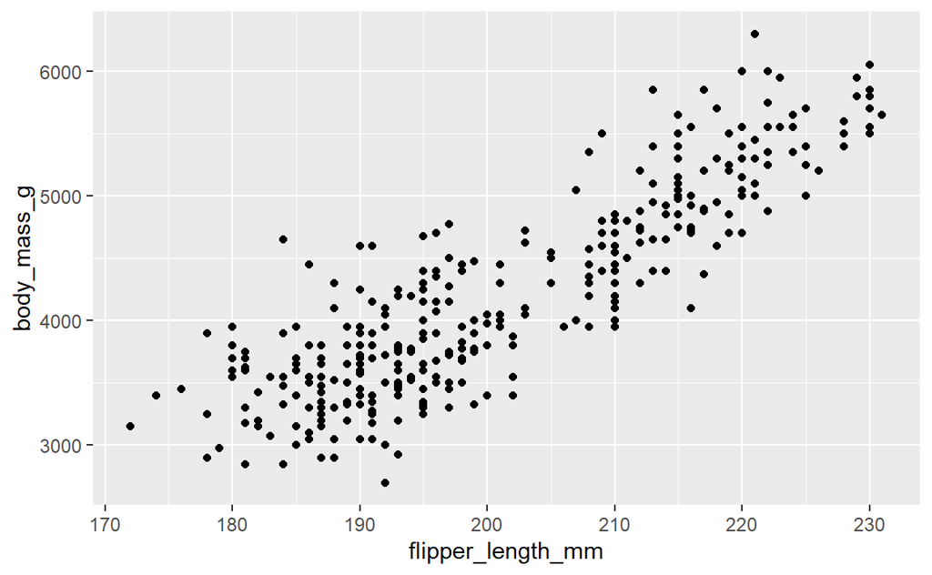

```r
ggplot(
  data = penguins,
  mapping = aes(x = flipper_length_mm, y = body_mass_g)
) +
  geom_point()
```

Now we have something that looks like what we might think of as a “scatterplot”. It doesn’t yet match our “ultimate goal” plot, but using this plot we can start answering the question that motivated our exploration: “What does the relationship between flipper length and body mass look like?” The relationship appears to be positive (as flipper length increases, so does body mass), fairly linear (the points are clustered around a line instead of a curve), and moderately strong (there isn’t too much scatter around such a line). Penguins with longer flippers are generally larger in terms of their body mass.

Before we add more layers to this plot, let’s pause for a moment and review the warning message we got:

> Removed 2 rows containing missing values (`geom_point()`).

We’re seeing this message because there are two penguins in our dataset with missing body mass and/or flipper length values and ggplot2 has no way of representing them on the plot without both of these values. Like R, ggplot2 subscribes to the philosophy that missing values should never silently go missing. This type of warning is probably one of the most common types of warnings you will see when working with real data – missing values are a very common issue. For the remaining plots in this chapter we will suppress this warning so it’s not printed alongside every single plot we make.

## Adding aesthetics and layers

Scatterplots are useful for displaying the relationship between two numerical variables, but it’s always a good idea to be skeptical of any apparent relationship between two variables and ask if there may be other variables that explain or change the nature of this apparent relationship. For example, does the relationship between flipper length and body mass differ by species? Let’s incorporate species into our plot and see if this reveals any additional insights into the apparent relationship between these variables. We will do this by representing species with different colored points.

To achieve this, will we need to modify the aesthetic or the geom? If you guessed “in the aesthetic mapping, inside of `aes()`”, you’re already getting the hang of creating data visualizations with ggplot2! And if not, don’t worry.

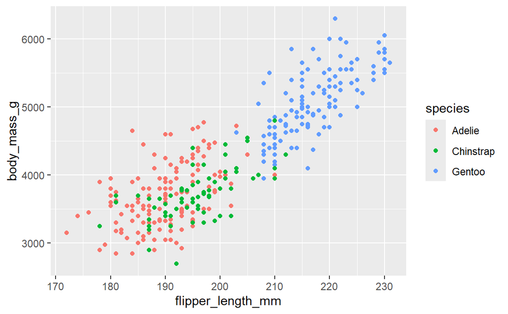

```r
ggplot(
  data = penguins,
  mapping = aes(x = flipper_length_mm, y = body_mass_g, color = species)
) +
  geom_point()
```

When a categorical variable is mapped to an aesthetic, ggplot2 will automatically assign a unique value of the aesthetic (here a unique color) to each unique level of the variable (each of the three species), a process known as **scaling**. ggplot2 will also add a legend that explains which values correspond to which levels.

Now let’s add one more layer: a smooth curve displaying the relationship between body mass and flipper length. Before you proceed, refer back to the code above, and think about how we can add this to our existing plot.

Since this is a new geometric object representing our data, we will add a new geom as a layer on top of our point geom: `geom_smooth()`. And we will specify that we want to draw the line of best fit based on a `l`inear `m`odel with `method = "lm"`.

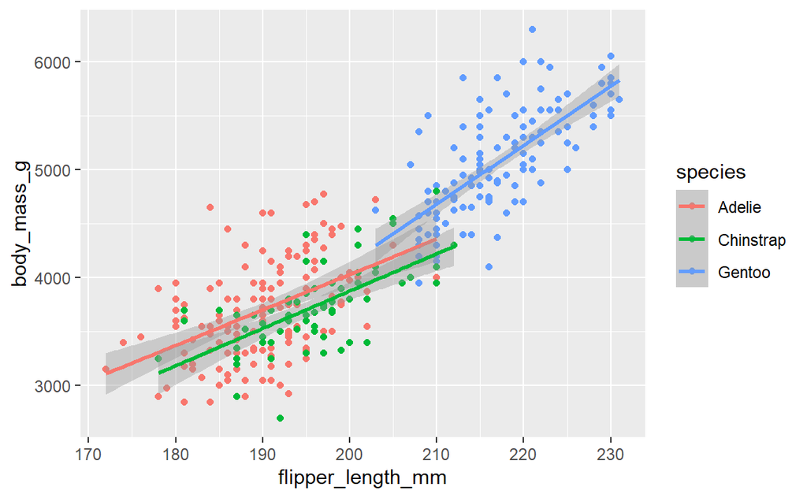

```r
ggplot(
  data = penguins,
  mapping = aes(x = flipper_length_mm, y = body_mass_g, color = species)
) +
  geom_point() +
  geom_smooth(method = "lm")
```

We have successfully added lines, but this plot doesn’t look like the plot from Figure 3, which only has one line for the entire dataset as opposed to separate lines for each of the penguin species.

When aesthetic mappings are defined in `ggplot()`, at the *global* level, they’re passed down to each of the subsequent geom layers of the plot. However, each geom function in ggplot2 can also take a `mapping` argument, which allows for aesthetic mappings at the *local* level that are added to those inherited from the global level. Since we want points to be colored based on species but don’t want the lines to be separated out for them, we should specify `color = species` for `geom_point()` only.

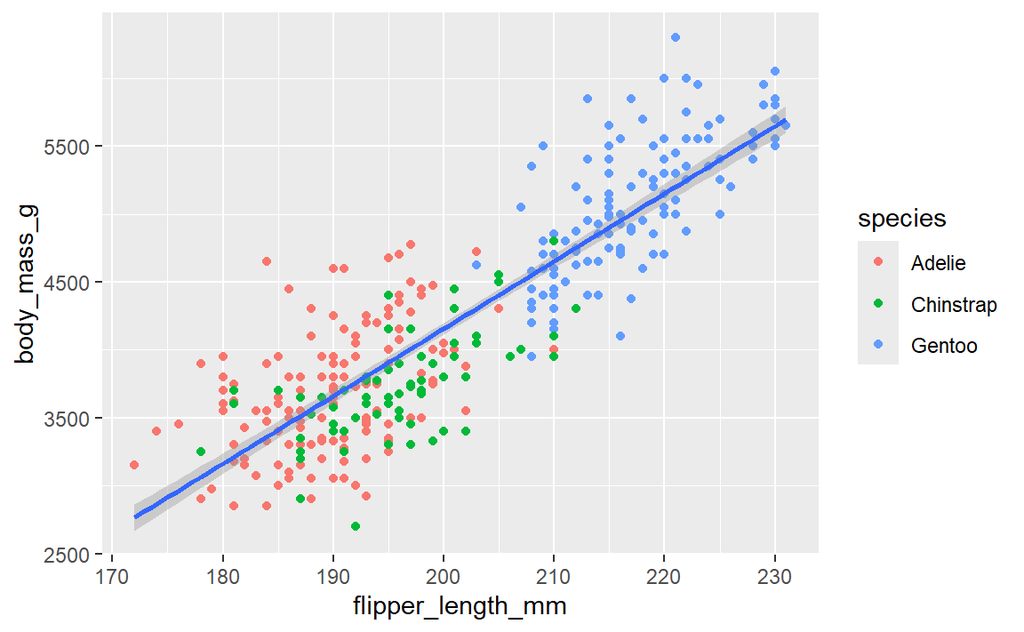

```r
ggplot(
  data = penguins,
  mapping = aes(x = flipper_length_mm, y = body_mass_g)
) +
  geom_point(mapping = aes(color = species)) +
  geom_smooth(method = "lm")
```

Voila! We have something that looks very much like our ultimate goal, though it’s not yet perfect. We still need to use different shapes for each species of penguins and improve labels.

It’s generally not a good idea to represent information using only colors on a plot, as people perceive colors differently due to color blindness or other color vision differences. Therefore, in addition to color, we can also map `species` to the `shape` aesthetic.

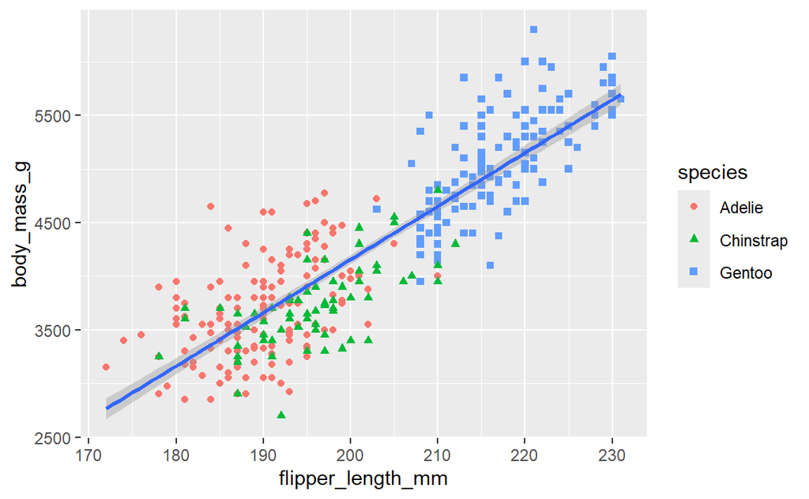

```r
ggplot(
  data = penguins,
  mapping = aes(x = flipper_length_mm, y = body_mass_g)
) +
  geom_point(mapping = aes(color = species, shape = species)) +
  geom_smooth(method = "lm")
```

Note that the legend is automatically updated to reflect the different shapes of the points as well.

And finally, we can improve the labels of our plot using the `labs()` function in a new layer. Some of the arguments to `labs()` might be self explanatory: `title` adds a title and `subtitle` adds a subtitle to the plot. Other arguments match the aesthetic mappings, `x` is the x-axis label, `y` is the y-axis label, and `color` and `shape` define the label for the legend. In addition, we can improve the color palette to use colours obtained from the ‘bright’ colour pallette in Paul Tol’s [website](https://personal.sron.nl/~pault/). To remove the grey background, we can use a different theme that is included with {ggplot2}. Here we will use `theme_minimal()`, but other options can be found [on the website](https://ggplot2.tidyverse.org/reference/ggtheme.html).

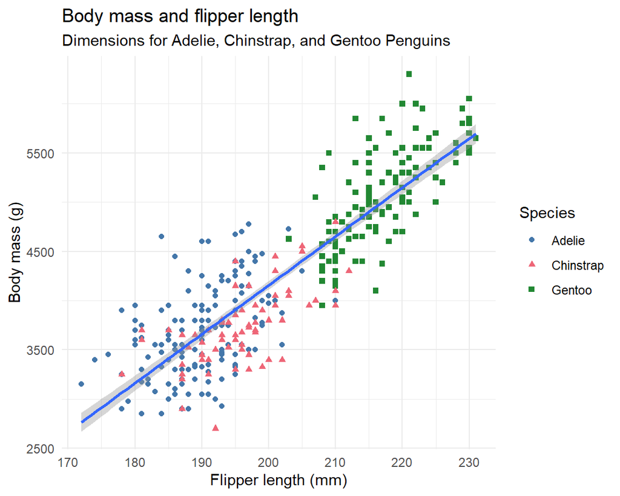

```r
ggplot(
  data = penguins,
  mapping = aes(x = flipper_length_mm, y = body_mass_g)
) +
  geom_point(aes(color = species, shape = species)) +
  geom_smooth(method = "lm") +
  labs(
    title = "Body mass and flipper length",
    subtitle = "Dimensions for Adelie, Chinstrap, and Gentoo Penguins",
    x = "Flipper length (mm)", y = "Body mass (g)",
    color = "Species", shape = "Species"
  ) +
  scale_color_manual(values = c("#4477AA", "#EE6677", "#228833")) +
  theme_minimal()
```

We finally have a plot that matches that shown in Figure 3!

# The Tidyverse

The tidyverse is a set of tools, originally created by [Hadley Wickham](https://hadley.nz/). All the packages within tidyverse share the same underlying design philosophy.

One key idea of the tidyverse is the *pipe*, either `%>%` or `|>`. The pipe can be thought of as a process for taking a tibble (or dataframe) on the left, and performing some function to it on the right. For example, to take the `penguins` dataset used in Section 3 and add a new variable that is the sum of the `bill_length_mm` and `flipper_length_mm`, we can use the `mutate()` function (from the [{dplyr} package](https://dplyr.tidyverse.org/)).

```r
penguins |>
  mutate(sum_of_bill_flipper = bill_length_mm + flipper_length_mm) |>
  glimpse()
```

**1**

Notice that here, we do not need to write `penguins$bill_length_mm`. This is because the pipe is telling `mutate()` that the dataset is `penguins`.

```
Rows: 344
Columns: 9
$ species             <fct> Adelie, Adelie, Adelie, Adelie, Adelie, Adelie, Ad…
$ island              <fct> Torgersen, Torgersen, Torgersen, Torgersen, Torger…
$ bill_length_mm      <dbl> 39.1, 39.5, 40.3, NA, 36.7, 39.3, 38.9, 39.2, 34.1…
$ bill_depth_mm       <dbl> 18.7, 17.4, 18.0, NA, 19.3, 20.6, 17.8, 19.6, 18.1…
$ flipper_length_mm   <int> 181, 186, 195, NA, 193, 190, 181, 195, 193, 190, 1…
$ body_mass_g         <int> 3750, 3800, 3250, NA, 3450, 3650, 3625, 4675, 3475…
$ sex                 <fct> male, female, female, NA, female, male, female, ma…
$ year                <int> 2007, 2007, 2007, 2007, 2007, 2007, 2007, 2007, 20…
$ sum_of_bill_flipper <dbl> 220.1, 225.5, 235.3, NA, 229.7, 229.3, 219.9, 234.…
```

**The Pipe**

Because of how popular the pipe has become, the pipe `|>` is now included in base R. The other pipe, `%>%`, is from the {magrittr} package. I will just use the base pipe here `|>`, although there are some slight differences as explained in the [tidyverse blog](https://www.tidyverse.org/blog/2023/04/base-vs-magrittr-pipe/).

Note that if your version of R is less that 4.1.0, the base pipe is not available. Therefore you will have to load tidyverse, `library(tidyverse)`, and use the {magrittr} pipe `%>%`.

## Examples of data wrangling in the tidyverse

Sticking with our `penguins` dataset, lets do some wrangling. Here we use functions that are part of the {dplyr} package, which is included in the tidyverse.

What if we want to find the average bill length per year?

```r
penguins |>
  group_by(year) |>
  summarise(average_bill = mean(bill_length_mm, na.rm = TRUE))
```

**1**

Start with the `penguins` dataset

**2**

Group by the year, so any functions after this point are performed on each year seperately

**3**

Use the [`summarise` function](https://dplyr.tidyverse.org/reference/summarise.html) to find the mean. We need to use `na.rm = TRUE` to remove the `NA` values.

```
# A tibble: 3 × 2
   year average_bill
  <int>        <dbl>
1  2007         43.7
2  2008         43.5
3  2009         44.5
```

We haven’t saved this summary dataset, as we did not assign it to a new variable.[^13]

<sup>13</sup> To assign it to a variable we need to use the `<-` operator:

```r
penguins_year_summary <- penguins |>
  group_by(year) |>
  summarise(average_bill = mean(bill_length_mm, na.rm = TRUE))
```

We can group by multiple variables. Here, we are finding the average bill length for each year and each species.

```r
penguins |>
  group_by(year, species) |>
  summarise(average_bill = mean(bill_length_mm, na.rm = TRUE))
```

```
# A tibble: 9 × 3
# Groups:   year [3]
   year species   average_bill
  <int> <fct>            <dbl>
1  2007 Adelie            38.8
2  2007 Chinstrap         48.7
3  2007 Gentoo            47.0
4  2008 Adelie            38.6
5  2008 Chinstrap         48.7
6  2008 Gentoo            46.9
7  2009 Adelie            39.0
8  2009 Chinstrap         49.1
9  2009 Gentoo            48.5
```

### Using `mutate()`

The `mutate()` function creates new columns that are functions of existing variables. It can also modify and delete columns.

```r
# square the body mass
penguins |>
  mutate(body_mass_squared_g = body_mass_g^2)
```

```
# A tibble: 344 × 9
   species island    bill_length_mm bill_depth_mm flipper_length_mm body_mass_g
   <fct>   <fct>              <dbl>         <dbl>             <int>       <int>
 1 Adelie  Torgersen           39.1          18.7               181        3750
 2 Adelie  Torgersen           39.5          17.4               186        3800
 3 Adelie  Torgersen           40.3          18                 195        3250
 4 Adelie  Torgersen           NA            NA                  NA          NA
 5 Adelie  Torgersen           36.7          19.3               193        3450
 6 Adelie  Torgersen           39.3          20.6               190        3650
 7 Adelie  Torgersen           38.9          17.8               181        3625
 8 Adelie  Torgersen           39.2          19.6               195        4675
 9 Adelie  Torgersen           34.1          18.1               193        3475
10 Adelie  Torgersen           42            20.2               190        4250
# ℹ 334 more rows
# ℹ 3 more variables: sex <fct>, year <int>, body_mass_squared_g <dbl>
```

```r
# telling mutate() that we want the column to go after the 'body_mass_g' column
penguins |>
  mutate(body_mass_squared_g = body_mass_g^2, .after = body_mass_g) |>
  glimpse()
```

```
Rows: 344
Columns: 9
$ species             <fct> Adelie, Adelie, Adelie, Adelie, Adelie, Adelie, Ad…
$ island              <fct> Torgersen, Torgersen, Torgersen, Torgersen, Torger…
$ bill_length_mm      <dbl> 39.1, 39.5, 40.3, NA, 36.7, 39.3, 38.9, 39.2, 34.1…
$ bill_depth_mm       <dbl> 18.7, 17.4, 18.0, NA, 19.3, 20.6, 17.8, 19.6, 18.1…
$ flipper_length_mm   <int> 181, 186, 195, NA, 193, 190, 181, 195, 193, 190, 1…
$ body_mass_g         <int> 3750, 3800, 3250, NA, 3450, 3650, 3625, 4675, 3475…
$ body_mass_squared_g <dbl> 14062500, 14440000, 10562500, NA, 11902500, 133225…
$ sex                 <fct> male, female, female, NA, female, male, female, ma…
$ year                <int> 2007, 2007, 2007, 2007, 2007, 2007, 2007, 2007, 20…
```

```r
# using glimpse()
penguins |>
  mutate(body_mass_squared_g = body_mass_g^2) |>
  glimpse()
```

**1**

Notice that `glimpse()` doesn’t have any arguments. That is because the pipe `|>` inputs the data into the argument of `glimpse()`.

```
Rows: 344
Columns: 9
$ species             <fct> Adelie, Adelie, Adelie, Adelie, Adelie, Adelie, Ad…
$ island              <fct> Torgersen, Torgersen, Torgersen, Torgersen, Torger…
$ bill_length_mm      <dbl> 39.1, 39.5, 40.3, NA, 36.7, 39.3, 38.9, 39.2, 34.1…
$ bill_depth_mm       <dbl> 18.7, 17.4, 18.0, NA, 19.3, 20.6, 17.8, 19.6, 18.1…
$ flipper_length_mm   <int> 181, 186, 195, NA, 193, 190, 181, 195, 193, 190, 1…
$ body_mass_g         <int> 3750, 3800, 3250, NA, 3450, 3650, 3625, 4675, 3475…
$ sex                 <fct> male, female, female, NA, female, male, female, ma…
$ year                <int> 2007, 2007, 2007, 2007, 2007, 2007, 2007, 2007, 20…
$ body_mass_squared_g <dbl> 14062500, 14440000, 10562500, NA, 11902500, 133225…
```

```r
# normalise the bill depth by the sample mean
penguins |>
  mutate(bill_depth_norm = bill_depth_mm / mean(bill_depth_mm, na.rm = TRUE))
```

```
# A tibble: 344 × 9
   species island    bill_length_mm bill_depth_mm flipper_length_mm body_mass_g
   <fct>   <fct>              <dbl>         <dbl>             <int>       <int>
 1 Adelie  Torgersen           39.1          18.7               181        3750
 2 Adelie  Torgersen           39.5          17.4               186        3800
 3 Adelie  Torgersen           40.3          18                 195        3250
 4 Adelie  Torgersen           NA            NA                  NA          NA
 5 Adelie  Torgersen           36.7          19.3               193        3450
 6 Adelie  Torgersen           39.3          20.6               190        3650
 7 Adelie  Torgersen           38.9          17.8               181        3625
 8 Adelie  Torgersen           39.2          19.6               195        4675
 9 Adelie  Torgersen           34.1          18.1               193        3475
10 Adelie  Torgersen           42            20.2               190        4250
# ℹ 334 more rows
# ℹ 3 more variables: sex <fct>, year <int>, bill_depth_norm <dbl>
```

Performing operations on multiple columns: here we are using the `across()` function to round the columns `bill_length_mm`, `bill_depth_mm`, and `flipper_length_mm` to the nearest integer. Note that here the columns are overwritten.

```r
penguins |>
  mutate(across(c(bill_length_mm, bill_depth_mm, flipper_length_mm), round))
```

```
# A tibble: 344 × 8
   species island    bill_length_mm bill_depth_mm flipper_length_mm body_mass_g
   <fct>   <fct>              <dbl>         <dbl>             <dbl>       <int>
 1 Adelie  Torgersen             39            19               181        3750
 2 Adelie  Torgersen             40            17               186        3800
 3 Adelie  Torgersen             40            18               195        3250
 4 Adelie  Torgersen             NA            NA                NA          NA
 5 Adelie  Torgersen             37            19               193        3450
 6 Adelie  Torgersen             39            21               190        3650
 7 Adelie  Torgersen             39            18               181        3625
 8 Adelie  Torgersen             39            20               195        4675
 9 Adelie  Torgersen             34            18               193        3475
10 Adelie  Torgersen             42            20               190        4250
# ℹ 334 more rows
# ℹ 2 more variables: sex <fct>, year <int>
```

### Using `select()`

We can use `select()` to select columns. The `:` operator selects a range of consecutive variables. The `!` operator negates a selection.

```r
penguins |>
  select(sex)
```

```
# A tibble: 344 × 1
   sex
   <fct>
 1 male
 2 female
 3 female
 4 <NA>
 5 female
 6 male
 7 female
 8 male
 9 <NA>
10 <NA>
# ℹ 334 more rows
```

```r
penguins |>
  select(body_mass_g:year)
```

```
# A tibble: 344 × 3
   body_mass_g sex     year
         <int> <fct>  <int>
 1        3750 male    2007
 2        3800 female  2007
 3        3250 female  2007
 4          NA <NA>    2007
 5        3450 female  2007
 6        3650 male    2007
 7        3625 female  2007
 8        4675 male    2007
 9        3475 <NA>    2007
10        4250 <NA>    2007
# ℹ 334 more rows
```

```r
penguins |>
  select(!sex)
```

```
# A tibble: 344 × 7
   species island    bill_length_mm bill_depth_mm flipper_length_mm body_mass_g
   <fct>   <fct>              <dbl>         <dbl>             <int>       <int>
 1 Adelie  Torgersen           39.1          18.7               181        3750
 2 Adelie  Torgersen           39.5          17.4               186        3800
 3 Adelie  Torgersen           40.3          18                 195        3250
 4 Adelie  Torgersen           NA            NA                  NA          NA
 5 Adelie  Torgersen           36.7          19.3               193        3450
 6 Adelie  Torgersen           39.3          20.6               190        3650
 7 Adelie  Torgersen           38.9          17.8               181        3625
 8 Adelie  Torgersen           39.2          19.6               195        4675
 9 Adelie  Torgersen           34.1          18.1               193        3475
10 Adelie  Torgersen           42            20.2               190        4250
# ℹ 334 more rows
# ℹ 1 more variable: year <int>
```

You can also select based on the name of the variables. Here we will select all variables that end with “_mm”.[^15]

<sup>15</sup> See the [tidyselect website](https://tidyselect.r-lib.org/reference/starts_with.html) for more information on pattern matching.

```r
penguins |>
  select(ends_with("_mm"))
```

```
# A tibble: 344 × 3
   bill_length_mm bill_depth_mm flipper_length_mm
            <dbl>         <dbl>             <int>
 1           39.1          18.7               181
 2           39.5          17.4               186
 3           40.3          18                 195
 4           NA            NA                  NA
 5           36.7          19.3               193
 6           39.3          20.6               190
 7           38.9          17.8               181
 8           39.2          19.6               195
 9           34.1          18.1               193
10           42            20.2               190
# ℹ 334 more rows
```

Or, all variables that do not end in “_mm”, using the `!` operator.

```r
penguins |>
  select(!ends_with("_mm"))
```

```
# A tibble: 344 × 5
   species island    body_mass_g sex     year
   <fct>   <fct>           <int> <fct>  <int>
 1 Adelie  Torgersen        3750 male    2007
 2 Adelie  Torgersen        3800 female  2007
 3 Adelie  Torgersen        3250 female  2007
 4 Adelie  Torgersen          NA <NA>    2007
 5 Adelie  Torgersen        3450 female  2007
 6 Adelie  Torgersen        3650 male    2007
 7 Adelie  Torgersen        3625 female  2007
 8 Adelie  Torgersen        4675 male    2007
 9 Adelie  Torgersen        3475 <NA>    2007
10 Adelie  Torgersen        4250 <NA>    2007
# ℹ 334 more rows
```

### Using `filter()`

The [`filter()` function](https://dplyr.tidyverse.org/reference/filter.html) keeps rows that match a condition.

For example, if we want to keep all rows that satisfy some condition on the bill length.

```r
# bill length must be greater than 40mm
penguins |>
  filter(bill_length_mm > 40)
```

```
# A tibble: 242 × 8
   species island    bill_length_mm bill_depth_mm flipper_length_mm body_mass_g
   <fct>   <fct>              <dbl>         <dbl>             <int>       <int>
 1 Adelie  Torgersen           40.3          18                 195        3250
 2 Adelie  Torgersen           42            20.2               190        4250
 3 Adelie  Torgersen           41.1          17.6               182        3200
 4 Adelie  Torgersen           42.5          20.7               197        4500
 5 Adelie  Torgersen           46            21.5               194        4200
 6 Adelie  Biscoe              40.6          18.6               183        3550
 7 Adelie  Biscoe              40.5          17.9               187        3200
 8 Adelie  Biscoe              40.5          18.9               180        3950
 9 Adelie  Dream               40.9          18.9               184        3900
10 Adelie  Dream               42.2          18.5               180        3550
# ℹ 232 more rows
# ℹ 2 more variables: sex <fct>, year <int>
```

```r
# bill length less than or equal to 35mm
penguins |>
  filter(bill_length_mm <= 35)
```

```
# A tibble: 11 × 8
   species island    bill_length_mm bill_depth_mm flipper_length_mm body_mass_g
   <fct>   <fct>              <dbl>         <dbl>             <int>       <int>
 1 Adelie  Torgersen           34.1          18.1               193        3475
 2 Adelie  Torgersen           34.6          21.1               198        4400
 3 Adelie  Torgersen           34.4          18.4               184        3325
 4 Adelie  Biscoe              35            17.9               190        3450
 5 Adelie  Biscoe              34.5          18.1               187        2900
 6 Adelie  Torgersen           33.5          19                 190        3600
 7 Adelie  Torgersen           34.6          17.2               189        3200
 8 Adelie  Dream               34            17.1               185        3400
 9 Adelie  Dream               33.1          16.1               178        2900
10 Adelie  Biscoe              35            17.9               192        3725
11 Adelie  Dream               32.1          15.5               188        3050
# ℹ 2 more variables: sex <fct>, year <int>
```

```r
# bill length is greater than the mean bill length
penguins |>
  filter(bill_length_mm > mean(bill_length_mm, na.rm = TRUE))
```

```
# A tibble: 175 × 8
   species island    bill_length_mm bill_depth_mm flipper_length_mm body_mass_g
   <fct>   <fct>              <dbl>         <dbl>             <int>       <int>
 1 Adelie  Torgersen           46            21.5               194        4200
 2 Adelie  Dream               44.1          19.7               196        4400
 3 Adelie  Torgersen           45.8          18.9               197        4150
 4 Adelie  Biscoe              45.6          20.3               191        4600
 5 Adelie  Torgersen           44.1          18                 210        4000
 6 Gentoo  Biscoe              46.1          13.2               211        4500
 7 Gentoo  Biscoe              50            16.3               230        5700
 8 Gentoo  Biscoe              48.7          14.1               210        4450
 9 Gentoo  Biscoe              50            15.2               218        5700
10 Gentoo  Biscoe              47.6          14.5               215        5400
# ℹ 165 more rows
# ℹ 2 more variables: sex <fct>, year <int>
```

```r
penguins |>
  group_by(species) |>
  filter(bill_length_mm > mean(bill_length_mm, na.rm = TRUE))
```

```
# A tibble: 172 × 8
# Groups:   species [3]
   species island    bill_length_mm bill_depth_mm flipper_length_mm body_mass_g
   <fct>   <fct>              <dbl>         <dbl>             <int>       <int>
 1 Adelie  Torgersen           39.1          18.7               181        3750
 2 Adelie  Torgersen           39.5          17.4               186        3800
 3 Adelie  Torgersen           40.3          18                 195        3250
 4 Adelie  Torgersen           39.3          20.6               190        3650
 5 Adelie  Torgersen           38.9          17.8               181        3625
 6 Adelie  Torgersen           39.2          19.6               195        4675
 7 Adelie  Torgersen           42            20.2               190        4250
 8 Adelie  Torgersen           41.1          17.6               182        3200
 9 Adelie  Torgersen           42.5          20.7               197        4500
10 Adelie  Torgersen           46            21.5               194        4200
# ℹ 162 more rows
# ℹ 2 more variables: sex <fct>, year <int>
```

In the ungrouped version, `filter()` compares the value of `bill_length_mm` in each row to the global average (taken over the whole data set), keeping only the rows with `bill_length_mm` greater than this global average. In contrast, the grouped version calculates the average `bill_length_mm` separately for each `species` group, and keeps rows with `bill_length_mm` greater than the relevant within-species average.

### Using `arrange()`

We can use `arrange()` to order the rows of a data frame.

```r
# arrange by body mass in ascending order
penguins |>
  arrange(body_mass_g)
```

```
# A tibble: 344 × 8
   species   island   bill_length_mm bill_depth_mm flipper_length_mm body_mass_g
   <fct>     <fct>             <dbl>         <dbl>             <int>       <int>
 1 Chinstrap Dream              46.9          16.6               192        2700
 2 Adelie    Biscoe             36.5          16.6               181        2850
 3 Adelie    Biscoe             36.4          17.1               184        2850
 4 Adelie    Biscoe             34.5          18.1               187        2900
 5 Adelie    Dream              33.1          16.1               178        2900
 6 Adelie    Torgers…           38.6          17                 188        2900
 7 Chinstrap Dream              43.2          16.6               187        2900
 8 Adelie    Biscoe             37.9          18.6               193        2925
 9 Adelie    Dream              37.5          18.9               179        2975
10 Adelie    Dream              37            16.9               185        3000
# ℹ 334 more rows
# ℹ 2 more variables: sex <fct>, year <int>
```

```r
# arrange by body mass in descending order
penguins |>
  arrange(desc(body_mass_g))
```

```
# A tibble: 344 × 8
   species island bill_length_mm bill_depth_mm flipper_length_mm body_mass_g
   <fct>   <fct>           <dbl>         <dbl>             <int>       <int>
 1 Gentoo  Biscoe           49.2          15.2               221        6300
 2 Gentoo  Biscoe           59.6          17                 230        6050
 3 Gentoo  Biscoe           51.1          16.3               220        6000
 4 Gentoo  Biscoe           48.8          16.2               222        6000
 5 Gentoo  Biscoe           45.2          16.4               223        5950
 6 Gentoo  Biscoe           49.8          15.9               229        5950
 7 Gentoo  Biscoe           48.4          14.6               213        5850
 8 Gentoo  Biscoe           49.3          15.7               217        5850
 9 Gentoo  Biscoe           55.1          16                 230        5850
10 Gentoo  Biscoe           49.5          16.2               229        5800
# ℹ 334 more rows
# ℹ 2 more variables: sex <fct>, year <int>
```

```r
# arrange by bill length and flipper length
penguins |>
  arrange(bill_length_mm, flipper_length_mm)
```

```
# A tibble: 344 × 8
   species island    bill_length_mm bill_depth_mm flipper_length_mm body_mass_g
   <fct>   <fct>              <dbl>         <dbl>             <int>       <int>
 1 Adelie  Dream               32.1          15.5               188        3050
 2 Adelie  Dream               33.1          16.1               178        2900
 3 Adelie  Torgersen           33.5          19                 190        3600
 4 Adelie  Dream               34            17.1               185        3400
 5 Adelie  Torgersen           34.1          18.1               193        3475
 6 Adelie  Torgersen           34.4          18.4               184        3325
 7 Adelie  Biscoe              34.5          18.1               187        2900
 8 Adelie  Torgersen           34.6          17.2               189        3200
 9 Adelie  Torgersen           34.6          21.1               198        4400
10 Adelie  Biscoe              35            17.9               190        3450
# ℹ 334 more rows
# ℹ 2 more variables: sex <fct>, year <int>
```

Note that `arrange()` ignores groupings unless specifically told not to. Have a look at the help file, `?arrange` to see for yourself.

```r
# group penguins by species
penguins_grouped <- penguins |>
  group_by(species)

# arrange() ignores grouping
penguins_grouped |>
  arrange(body_mass_g)
```

```
# A tibble: 344 × 8
# Groups:   species [3]
   species   island   bill_length_mm bill_depth_mm flipper_length_mm body_mass_g
   <fct>     <fct>             <dbl>         <dbl>             <int>       <int>
 1 Chinstrap Dream              46.9          16.6               192        2700
 2 Adelie    Biscoe             36.5          16.6               181        2850
 3 Adelie    Biscoe             36.4          17.1               184        2850
 4 Adelie    Biscoe             34.5          18.1               187        2900
 5 Adelie    Dream              33.1          16.1               178        2900
 6 Adelie    Torgers…           38.6          17                 188        2900
 7 Chinstrap Dream              43.2          16.6               187        2900
 8 Adelie    Biscoe             37.9          18.6               193        2925
 9 Adelie    Dream              37.5          18.9               179        2975
10 Adelie    Dream              37            16.9               185        3000
# ℹ 334 more rows
# ℹ 2 more variables: sex <fct>, year <int>
```

```r
# telling arrange() not to ignore the grouping
penguins_grouped |>
  arrange(body_mass_g, .by_group = TRUE)
```

```
# A tibble: 344 × 8
# Groups:   species [3]
   species island    bill_length_mm bill_depth_mm flipper_length_mm body_mass_g
   <fct>   <fct>              <dbl>         <dbl>             <int>       <int>
 1 Adelie  Biscoe              36.5          16.6               181        2850
 2 Adelie  Biscoe              36.4          17.1               184        2850
 3 Adelie  Biscoe              34.5          18.1               187        2900
 4 Adelie  Dream               33.1          16.1               178        2900
 5 Adelie  Torgersen           38.6          17                 188        2900
 6 Adelie  Biscoe              37.9          18.6               193        2925
 7 Adelie  Dream               37.5          18.9               179        2975
 8 Adelie  Dream               37            16.9               185        3000
 9 Adelie  Dream               37.3          16.8               192        3000
10 Adelie  Torgersen           35.9          16.6               190        3050
# ℹ 334 more rows
# ℹ 2 more variables: sex <fct>, year <int>
```

# Linear and Logistic Regression

We will continue looking at the `penguins` dataset here. First, lets get some summary statistics using the `summary()` function.

```r
summary(penguins)
```

```
      species          island    bill_length_mm  bill_depth_mm
 Adelie   :152   Biscoe   :168   Min.   :32.10   Min.   :13.10
 Chinstrap: 68   Dream    :124   1st Qu.:39.23   1st Qu.:15.60
 Gentoo   :124   Torgersen: 52   Median :44.45   Median :17.30
                                 Mean   :43.92   Mean   :17.15
                                 3rd Qu.:48.50   3rd Qu.:18.70
                                 Max.   :59.60   Max.   :21.50
                                 NA's   :2       NA's   :2
 flipper_length_mm  body_mass_g       sex           year
 Min.   :172.0     Min.   :2700   female:165   Min.   :2007
 1st Qu.:190.0     1st Qu.:3550   male  :168   1st Qu.:2007
 Median :197.0     Median :4050   NA's  : 11   Median :2008
 Mean   :200.9     Mean   :4202                Mean   :2008
 3rd Qu.:213.0     3rd Qu.:4750                3rd Qu.:2009
 Max.   :231.0     Max.   :6300                Max.   :2009
 NA's   :2         NA's   :2
```

## Linear regression

To perform linear regression, we can use the `lm()` function. The two main arguments of `lm()` are:

- `formula`: A formula in the form `y ~ x1 + x2 + ...` where `y` is the dependent variable, and `x1`, `x2`, … are the independent variables. If you want to include all columns (excluding y) as independent variables, just enter `y ~ .`
- `data`: The dataframe containing the columns specified in the formula.

Have a look at the helpfile, `?lm`, alongside the formula helpfile, `?formula`, to get a deeper understanding of how the function works. The `formula` syntax is also used in survival analysis in Section 6, so is important to understand.

### A simple linear model

Lets perform linear analysis on the penguin’s body mass and flipper length. We have seen this graphically in Figure 3 but we want to look in more detail at the intercepts and slope coefficients. We are assuming the linear model given by,

$$Y_{\text{body mass}} = \beta_0 + \beta_1 X_{\text{flipper length}} + \varepsilon,$$
where $\beta_0$ is the intercept and $\beta_1$ the coefficient for flipper length such that for every 1mm increase in flipper length, we expect body mass to increase by $\beta_1$. We assume that the residual term is distributed by some zero-mean Gaussian, $\varepsilon \sim N(0, \sigma_\varepsilon)$.

We have `body_mass_g` the dependent variable and `flipper_length_mm` the independent variable, so our `formula` is `body_mass_g ~ flipper_length_mm`.

```r
penguins_lm <- lm(body_mass_g ~ flipper_length_mm, data = penguins)

penguins_lm
```

```
Call:
lm(formula = body_mass_g ~ flipper_length_mm, data = penguins)

Coefficients:
      (Intercept)  flipper_length_mm
         -5780.83              49.69
```

**Using the pipe**

Note that with the `lm()` function, by looking at the help file, we can see that the `data =` argument is not the first one. This is different to how standard tidyverse function work, *e.g.* have a look at `?mutate`.[^16] This makes it a little trickier to use the pipe `|>`, as by default this pipes the left-hand side into the first argument of the right-hand side.

But, it can still be done, using `_` to clarify where we want the data piped to.

```r
penguins |>
  lm(body_mass_g ~ flipper_length_mm, data = _)
```

<sup>16</sup> The `lm()` function was created long before the tidyverse so doesn’t follow the same rules.

<sup>17</sup> `summary()` is a very general and very useful function that can be used on lots of different classes of data. For example, at the start of this chapter (Section 5) we applied the function to a tibble.

A more detailed output can be obtained using the `summary()` function.[^17]

```r
summary(penguins_lm)
```

```
Call:
lm(formula = body_mass_g ~ flipper_length_mm, data = penguins)

Residuals:
     Min       1Q   Median       3Q      Max
-1058.80  -259.27   -26.88   247.33  1288.69

Coefficients:
                   Estimate Std. Error t value Pr(>|t|)
(Intercept)       -5780.831    305.815  -18.90   <2e-16 ***
flipper_length_mm    49.686      1.518   32.72   <2e-16 ***
---
Signif. codes:  0 '***' 0.001 '**' 0.01 '*' 0.05 '.' 0.1 ' ' 1

Residual standard error: 394.3 on 340 degrees of freedom
  (2 observations deleted due to missingness)
Multiple R-squared:  0.759, Adjusted R-squared:  0.7583
F-statistic:  1071 on 1 and 340 DF,  p-value: < 2.2e-16
```

What does this output show?

- *Residuals*: a summary of the residuals, showing the minimum, maximum and quartiles.
- *Coefficients*:
  - the point estimate and standard error for the intercept and slope.
  - the t-value and p-value of the intercept and slopes
- *Residual standard error*: the standard deviation of the residuals, *i.e.* the typical deviation of the observed `body_mass_g` values from the predicted values.
- *R-squared and adjusted R-squared*: how much variability is explained by the model.
- *F-statistic*: testing overall model fit.

This linear model is the same as the line shown in Figure 3.

#### Evaluation model fit

1. *Residuals vs. Fitted plot*: used to look for underlying patterns in the residuals.
2. *Normal Q–Q plot*: used to check whether the residuals are normally distributed.
3. *Scale-location plot*: test the linear regression assumption of equal variance (homoscedasticity).
4. *Residuals vs. Leverage plot*: used to find influential cases in the dataset.

These are discussed in more detail on the [RPubs website](https://rpubs.com/iabrady/residual-analysis).

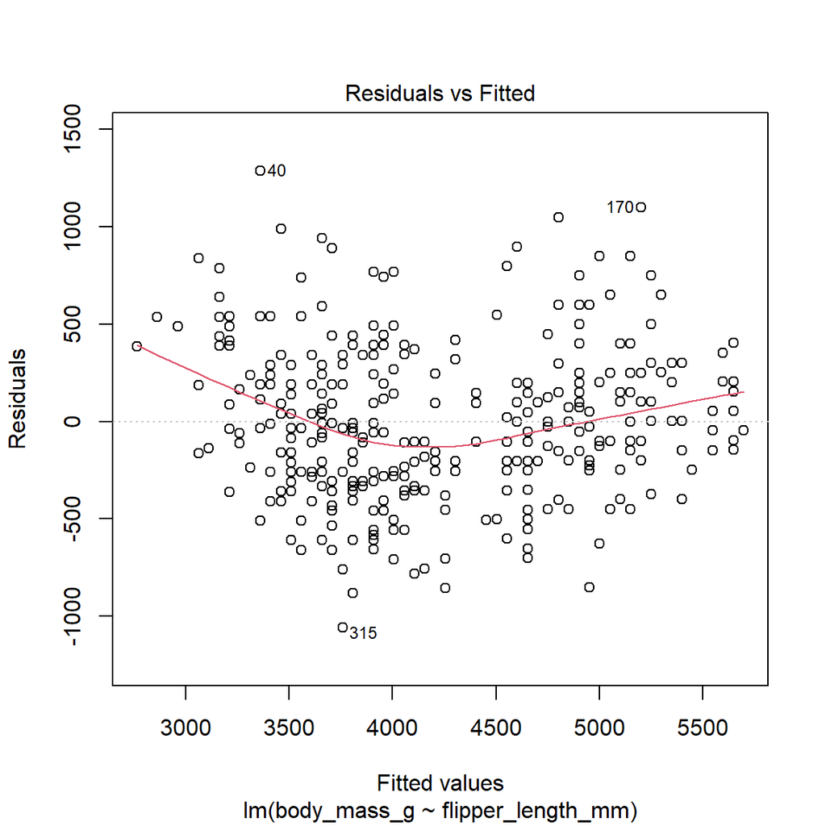

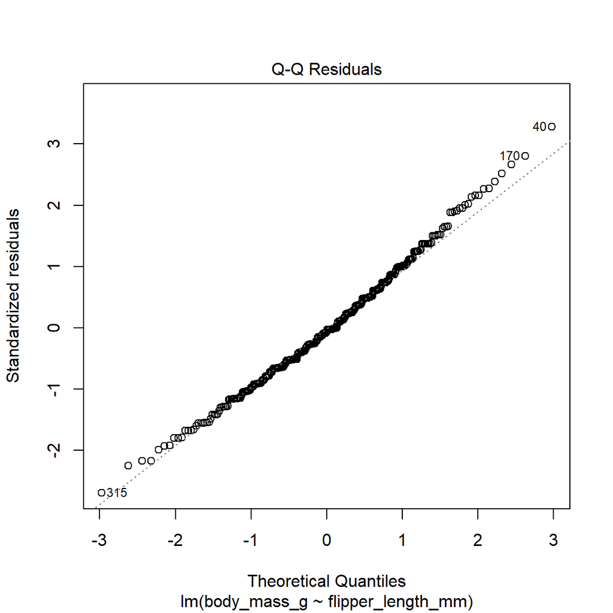

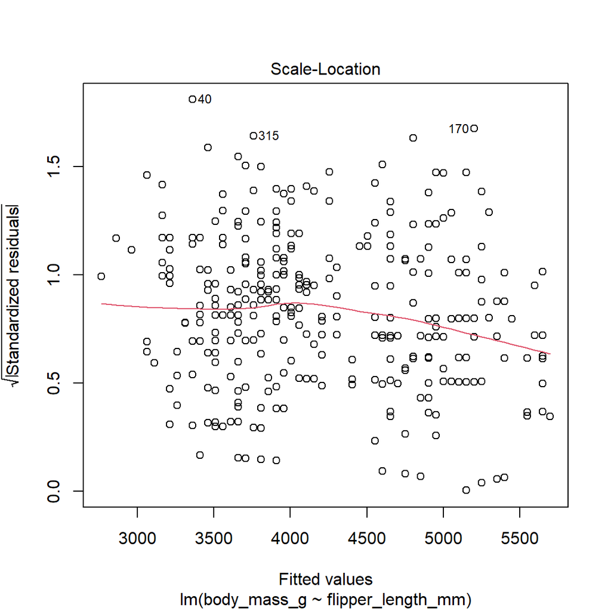

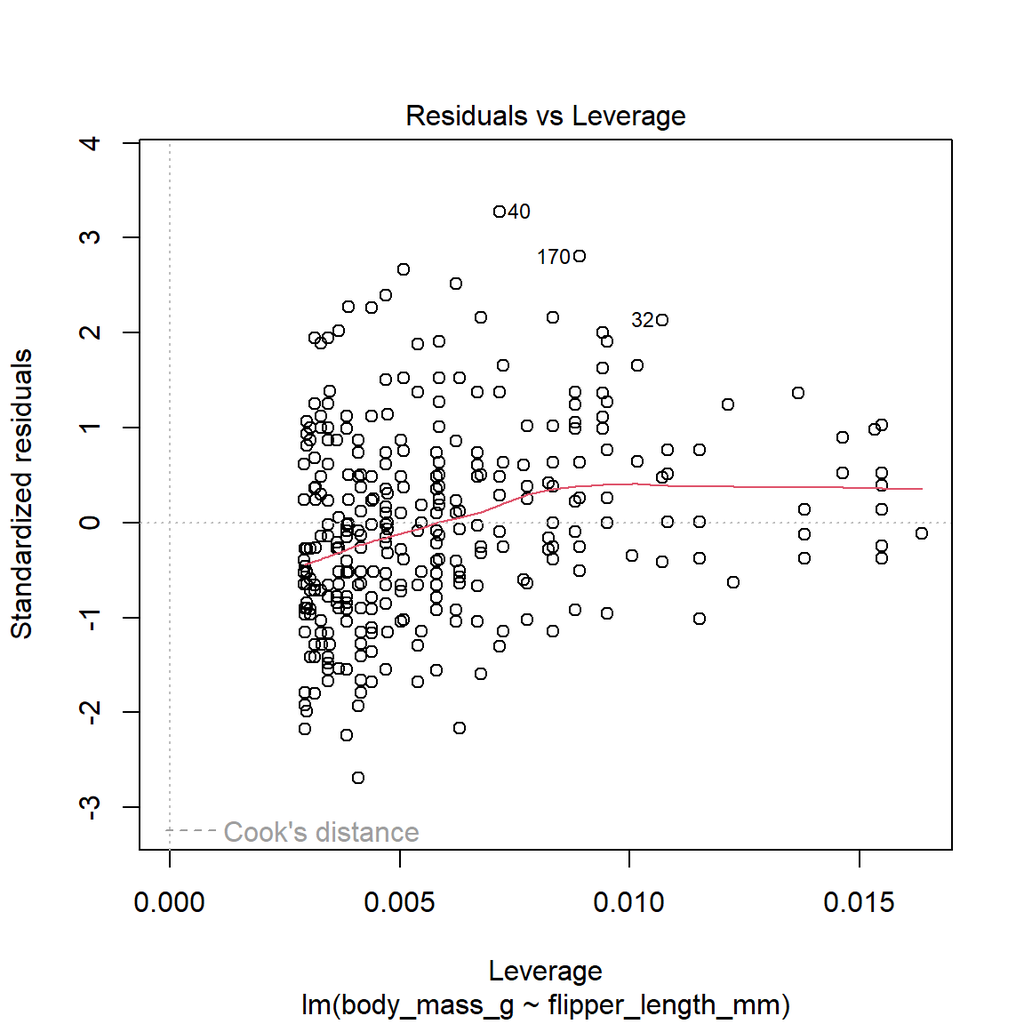

```r
plot(penguins_lm)
```

### Some more linear model examples

Some more examples of linear models.

```r
# modelling body mass by flipper length and sex.
penguins_lm2 <- lm(body_mass_g ~ flipper_length_mm + sex, data = penguins)
summary(penguins_lm2)
```

```
Call:
lm(formula = body_mass_g ~ flipper_length_mm + sex, data = penguins)

Residuals:
    Min      1Q  Median      3Q     Max
-910.28 -243.89   -2.94  238.85 1067.73

Coefficients:
                   Estimate Std. Error t value Pr(>|t|)
(Intercept)       -5410.300    285.798 -18.931  < 2e-16 ***
flipper_length_mm    46.982      1.441  32.598  < 2e-16 ***
sexmale             347.850     40.342   8.623 2.78e-16 ***
---
Signif. codes:  0 '***' 0.001 '**' 0.01 '*' 0.05 '.' 0.1 ' ' 1

Residual standard error: 355.9 on 330 degrees of freedom
  (11 observations deleted due to missingness)
Multiple R-squared:  0.8058,    Adjusted R-squared:  0.8047
F-statistic: 684.8 on 2 and 330 DF,  p-value: < 2.2e-16
```

```r
# modelling body mass by flipper length and the exponential log of bill_depth_mm
summary(lm(body_mass_g ~ flipper_length_mm + log(bill_depth_mm), data = penguins))
```

```
Call:
lm(formula = body_mass_g ~ flipper_length_mm + log(bill_depth_mm),
    data = penguins)

Residuals:
    Min      1Q  Median      3Q     Max
-1032.6  -273.4   -24.7   245.0  1277.2

Coefficients:
                    Estimate Std. Error t value Pr(>|t|)
(Intercept)        -7215.057    915.035  -7.885 4.35e-14 ***
flipper_length_mm     51.539      1.881  27.406  < 2e-16 ***
log(bill_depth_mm)   374.505    225.268   1.662   0.0973 .
---
Signif. codes:  0 '***' 0.001 '**' 0.01 '*' 0.05 '.' 0.1 ' ' 1

Residual standard error: 393.3 on 339 degrees of freedom
  (2 observations deleted due to missingness)
Multiple R-squared:  0.7609,    Adjusted R-squared:  0.7595
F-statistic: 539.5 on 2 and 339 DF,  p-value: < 2.2e-16
```

```r
# including all variables
summary(lm(body_mass_g ~ ., data = penguins))
```

```
Call:
lm(formula = body_mass_g ~ ., data = penguins)

Residuals:
    Min      1Q  Median      3Q     Max
-809.70 -180.87   -6.25  176.76  864.22

Coefficients:
                   Estimate Std. Error t value Pr(>|t|)
(Intercept)       84087.945  41912.019   2.006  0.04566 *
speciesChinstrap   -282.539     88.790  -3.182  0.00160 **
speciesGentoo       890.958    144.563   6.163 2.12e-09 ***
islandDream         -21.180     58.390  -0.363  0.71704
islandTorgersen     -58.777     60.852  -0.966  0.33482
bill_length_mm       18.964      7.112   2.667  0.00805 **
bill_depth_mm        60.798     20.002   3.040  0.00256 **
flipper_length_mm    18.504      3.128   5.915 8.46e-09 ***
sexmale             378.977     48.074   7.883 4.95e-14 ***
year                -42.785     20.949  -2.042  0.04194 *
---
Signif. codes:  0 '***' 0.001 '**' 0.01 '*' 0.05 '.' 0.1 ' ' 1

Residual standard error: 286.5 on 323 degrees of freedom
  (11 observations deleted due to missingness)
Multiple R-squared:  0.8768,    Adjusted R-squared:  0.8734
F-statistic: 255.4 on 9 and 323 DF,  p-value: < 2.2e-16
```

We can consider interactions, using `*`. This automatically includes the main effects in the model.[^18]

<sup>18</sup> You can also use `:` for interactions, but here you also have to specify the terms individually, e.g.

```r
lm(body_mass_g ~ flipper_length_mm + bill_depth_mm + flipper_length_mm : bill_depth_mm,
    data = penguins)
```

```r
summary(lm(body_mass_g ~ flipper_length_mm * bill_depth_mm, data = penguins))
```

```
Call:
lm(formula = body_mass_g ~ flipper_length_mm * bill_depth_mm,
    data = penguins)

Residuals:
    Min      1Q  Median      3Q     Max
-938.88 -253.96  -28.25  220.66 1048.33

Coefficients:
                                  Estimate Std. Error t value Pr(>|t|)
(Intercept)                     -36097.064   4636.271  -7.786 8.55e-14 ***
flipper_length_mm                  196.074     22.603   8.675  < 2e-16 ***
bill_depth_mm                     1771.796    273.003   6.490 3.06e-10 ***
flipper_length_mm:bill_depth_mm     -8.596      1.340  -6.414 4.78e-10 ***
---
Signif. codes:  0 '***' 0.001 '**' 0.01 '*' 0.05 '.' 0.1 ' ' 1

Residual standard error: 371.8 on 338 degrees of freedom
  (2 observations deleted due to missingness)
Multiple R-squared:  0.787, Adjusted R-squared:  0.7851
F-statistic: 416.2 on 3 and 338 DF,  p-value: < 2.2e-16
```

From this output, the interaction between flipper length and bill depth can be interpreted as follows: For every 1mm increase in both flipper length and bill depth, the predicted effect on body mass decreases by $8.596$ grams. The very small p-value ($4.78 \times 10^{−10}$) indicates strong evidence that the relationship between flipper length and body mass depends on bill depth.

## Logistic regression

The syntax for (binary) logistic regression is very similar to that for linear regression, except that the `g`eneralised `l`inear `m`odel function, `glm()` is used instead of `lm()`.

In this section we’ll be assuming that the dependent variable is `sex` – a binary variable. Let start with just considering `sex` against `bill_length_mm`.

```
Warning: Removed 2 rows containing missing values or values outside the scale range
(`geom_point()`).
```

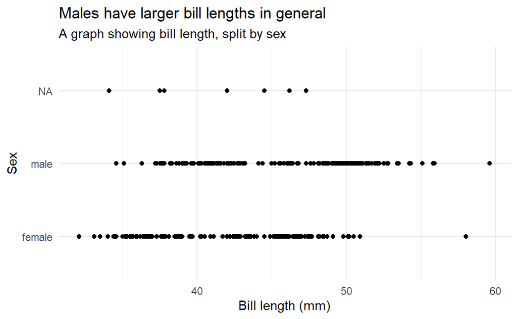

```r
ggplot(penguins, aes(x = bill_length_mm, y = sex)) +
  geom_point() +
  labs(
    title = "Males have larger bill lengths in general",
    subtitle = "A graph showing bill length, split by sex",
    x = "Bill length (mm)",
    y = "Sex"
  ) +
  theme_minimal()
```

I’m getting bored of the warnings about missing values, so lets remove all rows that contain an `NA` from our dataset.[^19]

<sup>19</sup> You should probably take care doing this if you are trying to do proper statistical analysis. There is a package called [`visdat`](https://cran.r-project.org/web/packages/visdat/vignettes/using_visdat.html) that can help you visualise data. In this case, it can create a plot showing where the missing data is and the class of each variable. Notice that here our `year` variable is of class integer, not date. If we had a full date (e.g. DD/MM/YY) we could change this to a Date class and use the [{lubridate}](https://lubridate.tidyverse.org/) package to perform operations.

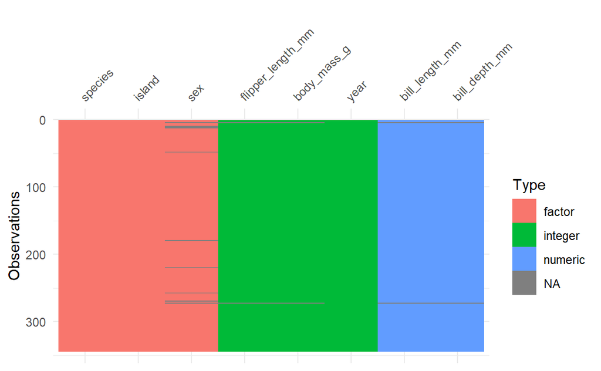

```r
library(visdat)
vis_dat(penguins)
```

```r
penguins_narm <- penguins |>
  na.omit()
```

Here we create a logistic regression model to predict the gender of the penguins.

```r
penguins_glm <- glm(sex ~ bill_length_mm,
                    data = penguins_narm, family = binomial(link = "logit"))
summary(penguins_glm)
```

**1**

A logistic regression model is a specific generalised linear model with the response variable modeled using a binomial distribution and a logit link function.

```
Call:
glm(formula = sex ~ bill_length_mm, family = binomial(link = "logit"),
    data = penguins_narm)

Coefficients:
               Estimate Std. Error z value Pr(>|z|)
(Intercept)    -6.03669    1.01229  -5.963 2.47e-09 ***
bill_length_mm  0.13770    0.02288   6.019 1.76e-09 ***
---
Signif. codes:  0 '***' 0.001 '**' 0.01 '*' 0.05 '.' 0.1 ' ' 1

(Dispersion parameter for binomial family taken to be 1)

    Null deviance: 461.61  on 332  degrees of freedom
Residual deviance: 420.42  on 331  degrees of freedom
AIC: 424.42

Number of Fisher Scoring iterations: 4
```

The model suggests that `bill_length_mm` is a significant predictor of `sex`. Specifically:

- For every 1-mm increase in bill_length_mm, the log odds of being in the other category (“Male”) increase by $0.138$.
- The coefficient is statistically significant, and therefore out model suggests that `bill_length_mm` is associated with `sex`.
- The odds ratio for `bill_length_mm` is $e^{0.1377} \approx 1.148$.[^20] This means that for every 1mm increase in bill length, the odds of being male are approximately $14.8 \%$ higher.

<sup>20</sup> The `str()` function comes in very handy when extracting specific bits of data from a dataset. Try typing `str(penguins_glm)`. This is a lot of information, but it allows us to see that the coefficients are stored in a vector called `coefficient`. This can be extracted using `penguins_glm$coefficients`. Therefore, `exp(penguins_glm$coefficients[2])` gives the odds ratio for `bill_length_mm`.

**Changing the reference level**

If we wanted `male` to be the reference level instead of `female`, we can reorder the `sex` factor levels using `fct_relevel()`.

```r
# look at the levels
levels(penguins_narm$sex)
```

**1**

The first factor in the output of `levels()` is used as the reference factor in `lm()` and `glm()`.

```
[1] "female" "male"
```

```r
# relevel 'sex' to make "male" the reference class
penguins_narm_relevel <- penguins_narm |>
  mutate(
    sex = fct_relevel(sex, "male")
  )
```

```r
# check the level order has changed
levels(penguins_narm_relevel$sex)
```

```
[1] "male"   "female"
```

```r
penguins_glm <- glm(sex ~ bill_length_mm,
                    data = penguins_narm, family = binomial(link = "logit"))
summary(penguins_glm)
```

```
Call:
glm(formula = sex ~ bill_length_mm, family = binomial(link = "logit"),
    data = penguins_narm)

Coefficients:
               Estimate Std. Error z value Pr(>|z|)
(Intercept)    -6.03669    1.01229  -5.963 2.47e-09 ***
bill_length_mm  0.13770    0.02288   6.019 1.76e-09 ***
---
Signif. codes:  0 '***' 0.001 '**' 0.01 '*' 0.05 '.' 0.1 ' ' 1

(Dispersion parameter for binomial family taken to be 1)

    Null deviance: 461.61  on 332  degrees of freedom
Residual deviance: 420.42  on 331  degrees of freedom
AIC: 424.42

Number of Fisher Scoring iterations: 4
```

# Performing survival analysis

To perform survival analysis in R, we need to get the [{survival} package](https://cran.r-project.org/package=survival).

```r
library(survival)
```

## Loading the example data

The {survival} package comes with lots of example dataset (write `data(package = "survival")` to see a list of them). We will be using the `lung` dataset. Currently, `lung` is a `data.frame`[^21], so lets convert to a tibble and view it.

<sup>21</sup> which can be seen by calling `class(lung)`

```r
lung <- as_tibble(lung)

glimpse(lung)
```

```
Rows: 228
Columns: 10
$ inst      <dbl> 3, 3, 3, 5, 1, 12, 7, 11, 1, 7, 6, 16, 11, 21, 12, 1, 22, 16…
$ time      <dbl> 306, 455, 1010, 210, 883, 1022, 310, 361, 218, 166, 170, 654…
$ status    <dbl> 2, 2, 1, 2, 2, 1, 2, 2, 2, 2, 2, 2, 2, 2, 2, 2, 2, 2, 2, 2, …
$ age       <dbl> 74, 68, 56, 57, 60, 74, 68, 71, 53, 61, 57, 68, 68, 60, 57, …
$ sex       <dbl> 1, 1, 1, 1, 1, 1, 2, 2, 1, 1, 1, 2, 2, 1, 1, 1, 1, 1, 2, 1, …
$ ph.ecog   <dbl> 1, 0, 0, 1, 0, 1, 2, 2, 1, 2, 1, 2, 1, NA, 1, 1, 1, 2, 2, 1,…
$ ph.karno  <dbl> 90, 90, 90, 90, 100, 50, 70, 60, 70, 70, 80, 70, 90, 60, 80,…
$ pat.karno <dbl> 100, 90, 90, 60, 90, 80, 60, 80, 80, 70, 80, 70, 90, 70, 70,…
$ meal.cal  <dbl> 1175, 1225, NA, 1150, NA, 513, 384, 538, 825, 271, 1025, NA,…
$ wt.loss   <dbl> NA, 15, 15, 11, 0, 0, 10, 1, 16, 34, 27, 23, 5, 32, 60, 15, …
```

We can look at the help file to see the desciptions of the variables by writing `?lung` in the console.

- `inst`: Institution code
- `time`: Survival time in days
- `status`: censoring status 1=censored, 2=dead
- `age`: Age in years
- `sex`: Male=1 Female=2
- `ph.ecog`: ECOG performance score as rated by the physician. 0=asymptomatic, 1=symptomatic but completely ambulatory, 2=in bed <50% of the day, 3=in bed >50% of the day but not bedbound, 4=bedbound
- `ph.karno`: Karnofsky performance score (bad=0-good=100) rated by physician
- `pat.karno`: Karnofsky performance score as rated by patient
- `meal.cal`: Calories consumed at meals
- `wt.loss`: Weight loss in last six months (pounds)

First, notice that all these variables are coded as `<dbl>`, *i.e.* floating point numbers. I want `inst`, `status`, `sex`, and `ph.ecog` to be factors. To do this, we use the `as_factor()` function from the {forcats} package (included in the tidyverse). Lets also change the levels of `sex` to “Male” and “Female” to make it clearer.

```r
lung <- lung |>
  mutate(
    across(c(inst, status, sex, ph.ecog), as_factor), # convert variables to factors
    sex = fct_recode(sex, Male = "1", Female = "2") # recode "1" to "Male" and "2" to "Female"
  )
```

**1**

Here we are replacing the original `lung` dataset with our new one.

Lets have a look at how many individuals were censored, and how many died.

```r
lung |>
  count(status)
```

```
# A tibble: 2 × 2
  status     n
  <fct>  <int>
1 1         63
2 2        165
```

So, we have 63 individuals who were censored, and 165 who died. The first thing to notice here is that the `status` variable is coded in a unusual way. Normally, this variable would be `0` for censored and `1` for dead. So, lets recode. Normally we would use the `recode()` function, but as we are dealing with factors, we can use `fct_recode()` instead.[^22]

<sup>22</sup> The `recode()` function would still work, but it transforms the column back to a `<dbl>`.

```r
lung <- lung |>
  mutate(
    status = fct_recode(status, `0` = "1", `1` = "2")
  )
# check that the frequency is still the same, but with the new coding
lung %>%
  count(status)
```

```
# A tibble: 2 × 2
  status     n
  <fct>  <int>
1 0         63
2 1        165
```

OK, we have a nicer dataset now. Lets look at doing some survival analysis.

## Creating a survival object

The core functions of the {survival} package include:

- `Surv()`: Creates a survival object.
- `survfit()`: Fits a survival curve using either a formula, of from a previously fitted Cox model.
- `coxph()`: Fits a Cox proportional hazards regression model.
- `cox.zph()`: Tests the proportional hazards assumption of a Cox regression model.
- `survdiff()`: Tests for differences in survival between two groups using a log-rank / Mantel-Haenszel test.6

To create a survival object from our `lung` dataset, we can run the following.

```r
s <- Surv(lung$time, lung$status)

# lets look at the first ten elements of the output
s[1:10]
```

```
 [1]  306:1  455:1 1010+   210:1  883:1 1022+   310:1  361:1  218:1  166:1
```

Run `class(s)` is your console to check that `s` is a survival object, `Surv`. The elements of a survival object are in the format `<time>:<status>` or `<time>+`, where

- `<time>` is the survival time (here, days).
- `<status>` indicates whether the event occurred (`1` for death) or the observation was censored (`0` for censored).
- The `+` symbol represents censored observations.

**Did we need to recode the `status` variable?**

Run `?Surv` in the console and have a look at the “Note” section near the bottom.

*A question*: what would the output look like if we didn’t record the `status` variable to 0 / 1? Would it make a different?

## Fitting a survival curve

To fit a survival curve, we use the `survfit()` function. To create a simple survival curve that doesn’t consider any different groupings, we just specify the intercept, `~1`, in the `formula` argument.[^23]

<sup>23</sup> Look at `?survfit` for help.

```r
sfit <- survfit(s ~ 1)

sfit
```

**1**

There are different ways to write this. For example, if we hadn’t already created our survival object `s`, we could do it all in one line, `survfit(Surv(time, status) ~ 1, data = lung)`

```
Call: survfit(formula = s ~ 1)

       n nevent    rmean se(rmean)*
(s0) 228      0 376.2747   19.70779
1    228    165 645.7253   19.70779
   *restricted mean time in state (max time = 1022 )
```

The output from `sfit` shows some things,[^24] but for a more interesting output, we can use the `summary()` function to show the number at risk and the cumulative survival at each event. Here, I have put the output of the `summary()` function into a different tab, so that it doesn’t take up lots of space.

<sup>24</sup> The key components of `sfit` are:

- `n`: The total number of individuals in the dataset (228).
- `nevent`: The number of events (deaths) observed in the data (165).
- `rmean`: The restricted mean survival time (time spent in a particular state up to a maximum time of 1022 days). It is broken into two states:
  - `(s0)`: Time in the “alive” state before transitioning (376.27 days on average).
  - `1`: Time in the “event” state (645.73 days on average).
- `se(rmean)`: Standard error of the restricted mean survival time.

**R code**

```r
summary(sfit)
```

**Output**

```
Call: survfit(formula = s ~ 1)

 time n.risk n.event Pr((s0))   Pr(1)
    5    228       1   0.9956 0.00439
   11    227       3   0.9825 0.01754
   12    224       1   0.9781 0.02193
   13    223       2   0.9693 0.03070
   15    221       1   0.9649 0.03509
   26    220       1   0.9605 0.03947
   30    219       1   0.9561 0.04386
   31    218       1   0.9518 0.04825
   53    217       2   0.9430 0.05702
   54    215       1   0.9386 0.06140
   59    214       1   0.9342 0.06579
   60    213       2   0.9254 0.07456
```

[output cut: 127 more lines]

The `summary()` function gives a more detailed breakdown of the Kaplan-Meier survival curve at specific time points, including:

- `time`: Specific time points where an event (death) occurred or censoring was recorded.
- `n.risk`: The number of individuals at risk of experiencing the event at that time.
- `n.event`: The number of events (deaths) that occurred at each time point.
- `Pr((s0))`: The survival probability (*i.e.* the probability of staying in the initial state (alive) at that time).
- `Pr(1)`: The cumulative probability of transitioning to the event state (death), *i.e.* 1 - survival probability.

For example, at `time = 5`, we have:

```
 time n.risk n.event Pr((s0))   Pr(1)
    5    228       1   0.9956 0.00439
```

- `n.risk`: 228 individuals at risk at day 5.
- `n.event`: 1 individual died at day 5.
- `Pr((s0)) = 0.9956`: Survival probability after day 5 is 99.56%.
- `Pr(1) = 0.00439`: Cumulative probability of death by day 5 is 0.44%.